# IODS course project

Antti Korhonen

# 1 Introduction to Open Data Science - Course Project

# 2 About the project

*I noticed this course from some UEF yammer group. One hope is that during this course we would learn how to extract data from open data interfaces, although not sure if this is part of the course agenda. Perhaps I am not fully realized yet what is this course about, but the course name "Introduction to open data science" raised my interest towards this course. Link to my GitHub repository: https://github.com/ahtk288/IODS-project*

```r
# This is a so-called "R chunk" where you can write R code.

date()
```

```
## [1] "Thu Dec 03 18:03:07 2020"
```

The text continues here.

# 3 Exercise 2. Regression and model validation

*During this weeks work we learned some preprocessing of the data by scaling combination variables to original scales and excluding unneeded variables and observations from the data. Further we learned how to get overview of the data by calculating summary statistics and by making plots (e.g scatter plot). With regression model we learned to create a model to see which variables affected most to exam points. Validity of the selected regression model graphically exlored with residuals vs. fitted, quantile-quantile and residuals vs. leverage plots.*

```r
# #### DATA ANALYSIS ####

date()
```

```
## [1] "Thu Dec 03 18:03:07 2020"
```

```r
#### TASK 1 ####
# reading in and structure of the data

# packages needed
library(data.table)
library(ggplot2)

# Reading the learning 2014 data into R, using fread function of data.table package
learning2014 <- fread("F:/IODS_usb/IODS-project/data/learning2014.csv")

# structure and dimensions of the data
# data.frame with 166 obs. (students) of 7 variables (gender, age, attitude, deep, stra, surf, points)
str(learning2014)
```

```
## Classes 'data.table' and 'data.frame':   166 obs. of  7 variables:
##  $ gender  : chr  "F" "M" "F" "M" ...
##  $ age     : int  53 55 49 53 49 38 50 37 37 42 ...
##  $ attitude: num  3.7 3.1 2.5 3.5 3.7 3.8 3.5 2.9 3.8 2.1 ...
##  $ deep    : num  3.58 2.92 3.5 3.5 3.67 ...
##  $ stra    : num  3.38 2.75 3.62 3.12 3.62 ...
##  $ surf    : num  2.58 3.17 2.25 2.25 2.83 ...
##  $ points  : int  25 12 24 10 22 21 21 31 24 26 ...
##  - attr(*, ".internal.selfref")=<externalptr>
```

```r
dim(learning2014)
```

```
## [1] 166   7
```

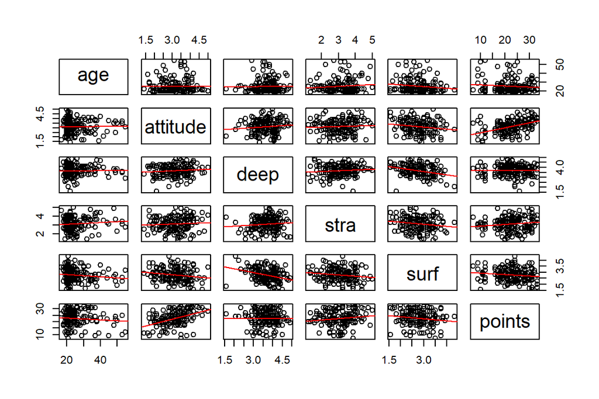

```r
#### TASK 2 ####
# a graphical overview and summaries of the data

# to fit the sraight line with lm in scatterplot matrix
# https://stackoverflow.com/questions/39667830/how-to-insert-trendlines-in-scatterplot-matrix

panel.lm <- function (x, y,  pch = par("pch"), col.lm = "red",  ...) {
  ymin <- min(y)
  ymax <- max(y)
  xmin <- min(x)
  xmax <- max(x)
  ylim <- c(min(ymin,xmin),max(ymax,xmax))
  xlim <- ylim
  points(x, y, pch = pch,ylim = ylim, xlim= xlim,...)
  ok <- is.finite(x) & is.finite(y)
  if (any(ok))
    abline(lm(y[ok]~ x[ok]),
           col = col.lm, ...)
}

# draw a scatter plot matrix of the variables in learning2014.
# [,2:7] excludes the first column (gender)
pairs(learning2014[,2:7], panel = panel.lm)
```

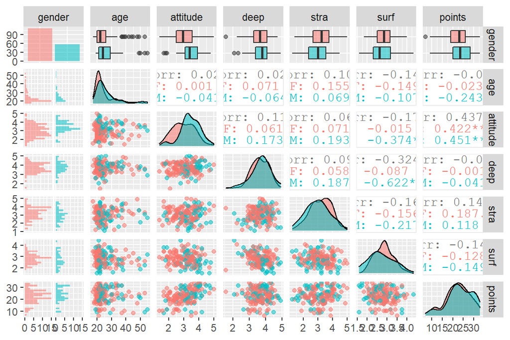

```r
# access the GGally and ggplot2 libraries
library(GGally)
library(ggplot2)

# create a more advanced plot matrix with ggpairs() and draw the plot. Divided by gender
p <- ggpairs(learning2014, mapping = aes(col = gender, alpha = 0.3), lower = list(combo = wrap("facethist", bins = 20)))
p
```

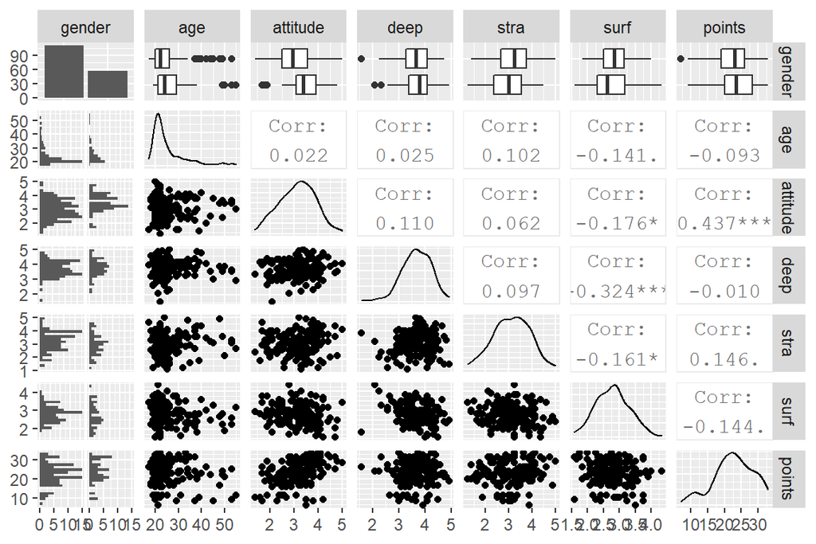

```r
# create an plot matrix with ggpairs(). All subjects
ggpairs(learning2014, lower = list(combo = wrap("facethist", bins = 20)))
```

```r
# summaries of the variables
summary(learning2014)
```

```
##     gender               age           attitude          deep
##  Length:166         Min.   :17.00   Min.   :1.400   Min.   :1.583
##  Class :character   1st Qu.:21.00   1st Qu.:2.600   1st Qu.:3.333
##  Mode  :character   Median :22.00   Median :3.200   Median :3.667
##                     Mean   :25.51   Mean   :3.143   Mean   :3.680
##                     3rd Qu.:27.00   3rd Qu.:3.700   3rd Qu.:4.083
##                     Max.   :55.00   Max.   :5.000   Max.   :4.917
##       stra            surf           points
##  Min.   :1.250   Min.   :1.583   Min.   : 7.00
##  1st Qu.:2.625   1st Qu.:2.417   1st Qu.:19.00
##  Median :3.188   Median :2.833   Median :23.00
##  Mean   :3.121   Mean   :2.787   Mean   :22.72
##  3rd Qu.:3.625   3rd Qu.:3.167   3rd Qu.:27.75
##  Max.   :5.000   Max.   :4.333   Max.   :33.00
```

```r
#### TASKS 3 AND 4 ####

# create a regression model with multiple explanatory variables
my_model2 <- lm(points ~ attitude+stra+age, data = learning2014)

# print out a summary of the model
summary(my_model2)
```

```
##
## Call:
## lm(formula = points ~ attitude + stra + age, data = learning2014)
##
## Residuals:
##      Min       1Q   Median       3Q      Max
## -18.1149  -3.2003   0.3303   3.4129  10.7599
##
## Coefficients:
##             Estimate Std. Error t value Pr(>|t|)
## (Intercept) 10.89543    2.64834   4.114 6.17e-05 ***
## attitude     3.48077    0.56220   6.191 4.72e-09 ***
## stra         1.00371    0.53434   1.878   0.0621 .
## age         -0.08822    0.05302  -1.664   0.0981 .
## ---
## Signif. codes:  0 '***' 0.001 '**' 0.01 '*' 0.05 '.' 0.1 ' ' 1
##
## Residual standard error: 5.26 on 162 degrees of freedom
## Multiple R-squared:  0.2182, Adjusted R-squared:  0.2037
## F-statistic: 15.07 on 3 and 162 DF,  p-value: 1.07e-08
```

```r
# create a regression model with multiple explanatory variables
my_model2 <- lm(points ~ attitude, data = learning2014)

# print out a summary of the model
summary(my_model2)
```

```
##
## Call:
## lm(formula = points ~ attitude, data = learning2014)
##
## Residuals:
##      Min       1Q   Median       3Q      Max
## -16.9763  -3.2119   0.4339   4.1534  10.6645
##
## Coefficients:
##             Estimate Std. Error t value Pr(>|t|)
## (Intercept)  11.6372     1.8303   6.358 1.95e-09 ***
## attitude      3.5255     0.5674   6.214 4.12e-09 ***
## ---
## Signif. codes:  0 '***' 0.001 '**' 0.01 '*' 0.05 '.' 0.1 ' ' 1
##
## Residual standard error: 5.32 on 164 degrees of freedom
## Multiple R-squared:  0.1906, Adjusted R-squared:  0.1856
## F-statistic: 38.61 on 1 and 164 DF,  p-value: 4.119e-09
```

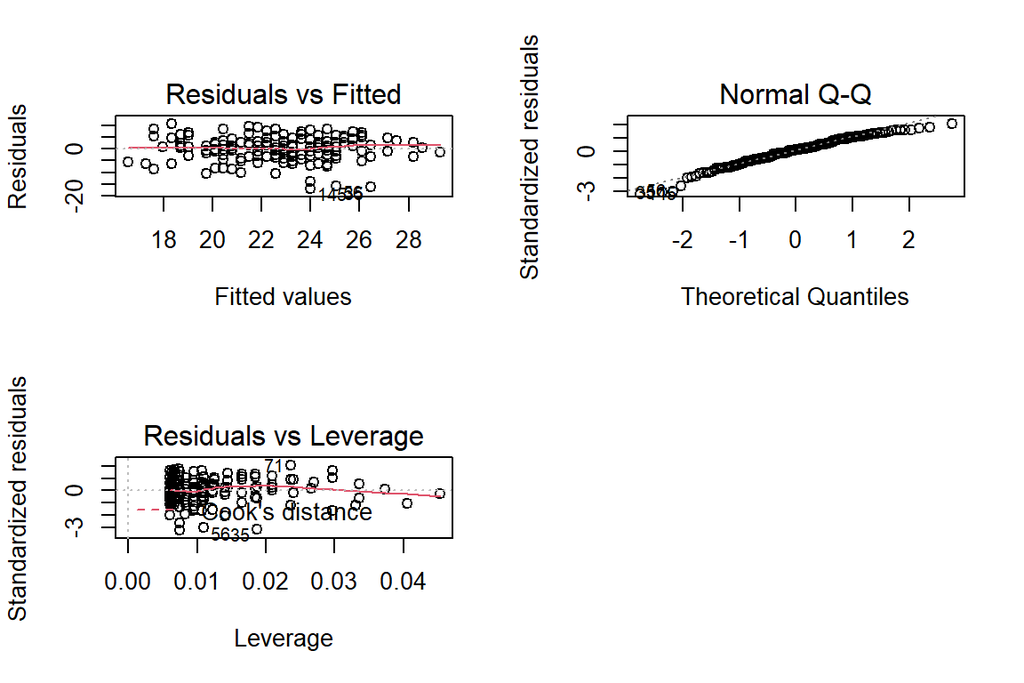

```r
#### TASK 5 ####

# draw diagnostic plots using the plot() function. Choose the plots 1 (residual vs. fitted),
# 2 (Normal QQ-plot) and 5 (Residuals vs. leverage)
par(mfrow = c(2,2))
plot(my_model2, which = c(1,2,5))
```

TASK 1 Dataframe "learning2014" had 166 observations (students) and 7 variables (gender, age, attitude, deep, stra, surf, points).

TASK 2

Median age of the students were 22 ranging from 17 to 55 years. Median of the exam points was 23 (min.7 and max.33). Variables attitude, deep, stra and surf were in the scale ranging from 1 to 5. Higher the number the better.

TASKS 3 AND 4

Three variables that I chose to the model were were attitude, age and stra (summary of the model in lines 92-109). This model explained 22% (R2) of the variance in exam points (adjusted R2, 20 %). The model itself was statistically significant (p value < 0.05). Only attitude in this model had p-value lower than 0.05, so I removed variables age and stra from the model. Attitude alone explained 19 % of the variability of the exam points.

TASK 5

Validity of the model (points ~ attitude) assumptions was graphically explored with residuals vs. fitted, normal quantile-quantile (QQ) and residuals vs. leverage plots

Residuals vs. fitted

QQ plot of the residuals

QQ plot checks are the errors of the model normally distributed. There was reasonable fit with the line. Only tails deviated a little from the dashed line. In the lower left corner of the plot there were possibly two outliers (35, 56, 145)

Residual vs. Leverage

This plot helps to identify possible influential outliers in a linear regression model. Based on this plot there were no influential outliers that were affecting to the model.

# 4 Exercise 3. Logistic regression

*In this exercise we first merged two datasets and created new variables e.g. by calculating averages of weekday and weekend alcohol consumptions.Further we analyzed relationships between alcohol consumption and selected variables by using logistic regression model and odds ratios and explored the predictive power of the model. I studied how alcohol consumption affected to number of school absences and class failures, grades and quality of family relationships.*

**TASKS 1 AND 2**

The data have 370 observations (students) of 51 variables. Information related to the data is presented in the following [link](https://archive.ics.uci.edu/ml/datasets/Student+Performance).

```r
# TASK 1

date()
```

```
## [1] "Thu Dec 03 18:03:27 2020"
```

```r
# read in the data using fread function of data.table package
library(data.table)
alc_consu <- fread("F:/IODS_usb/IODS-project/data/pormath.csv")

# get the names of the variables
names(alc_consu)
```

```
##  [1] "school"     "sex"        "age"        "address"    "famsize"
##  [6] "Pstatus"    "Medu"       "Fedu"       "Mjob"       "Fjob"
## [11] "reason"     "guardian"   "traveltime" "studytime"  "schoolsup"
## [16] "famsup"     "activities" "nursery"    "higher"     "internet"
## [21] "romantic"   "famrel"     "freetime"   "goout"      "Dalc"
## [26] "Walc"       "health"     "n"          "id.p"       "id.m"
## [31] "failures"   "paid"       "absences"   "G1"         "G2"
## [36] "G3"         "failures.p" "paid.p"     "absences.p" "G1.p"
## [41] "G2.p"       "G3.p"       "failures.m" "paid.m"     "absences.m"
## [46] "G1.m"       "G2.m"       "G3.m"       "alc_use"    "high_use"
## [51] "cid"
```

**TASK 3**

I chose variables (i) absence (number of school absences), (ii) failure (no. of past class failures), (iii) G3 (final grade ranging from 0-20) and (iv) famrel (quality of family relationships 1= very bad and 5= excellent).

Alcohol consumption was graded from 1 (1=very low) to 5 (=very high). Division between low and high users (variable high_use) was created by using alcohol consumption of 2 as threshold. Those students whose workday and weekend consumption was higher than 2 were high consumers. So my hypotheses were that higher alcohol consumption lead to higher number of absences and failures, lower grades and these subjects did have lower quality relationship with their family.

**TASK 4**

In total out of 370 students there were 111 high alcohol consumers (41 females and 70 males).

Bit surprisingly high consuming females had better grades (11.8) than low consumers (11.4). High consuming males had clearly lower grades (10.3) than low consuming males (12.3)

Quality of family relationships were bit poorer in high consuming groups (F:3.7 and M:3.8) in comparison to low consuming groups (F:3.9 and M:4.1).

All in all my hypotheses seemed to be correct although females who consumed more alcohol had better grades in comparison to low consuming females.

```r
# TASK 4, numerical summary

# access the tidyverse libraries dplyr and ggplot2
library(dplyr); library(ggplot2)

# produce summary statistics by group
alc_consu %>% group_by(sex, high_use) %>% summarise(count = n(), mean_grade = mean(G3))
```

```
## # A tibble: 4 x 4
## # Groups:   sex [2]
##   sex   high_use count mean_grade
##   <chr> <lgl>    <int>      <dbl>
## 1 F     FALSE      154       11.4
## 2 F     TRUE        41       11.8
## 3 M     FALSE      105       12.3
## 4 M     TRUE        70       10.3
```

```r
alc_consu %>% group_by(sex, high_use) %>% summarise(count = n(), mean_grade = mean(absences))
```

```
## # A tibble: 4 x 4
## # Groups:   sex [2]
##   sex   high_use count mean_grade
##   <chr> <lgl>    <int>      <dbl>
## 1 F     FALSE      154       4.25
## 2 F     TRUE        41       6.85
## 3 M     FALSE      105       2.91
## 4 M     TRUE        70       6.1
```

```r
alc_consu %>% group_by(sex, high_use) %>% summarise(count = n(), mean_grade = mean(failures))
```

```
## # A tibble: 4 x 4
## # Groups:   sex [2]
##   sex   high_use count mean_grade
##   <chr> <lgl>    <int>      <dbl>
## 1 F     FALSE      154      0.104
## 2 F     TRUE        41      0.293
## 3 M     FALSE      105      0.143
## 4 M     TRUE        70      0.386
```

```r
alc_consu %>% group_by(sex, high_use) %>% summarise(count = n(), mean_grade = mean(famrel))
```

```
## # A tibble: 4 x 4
## # Groups:   sex [2]
##   sex   high_use count mean_grade
##   <chr> <lgl>    <int>      <dbl>
## 1 F     FALSE      154       3.92
## 2 F     TRUE        41       3.73
## 3 M     FALSE      105       4.13
## 4 M     TRUE        70       3.79
```

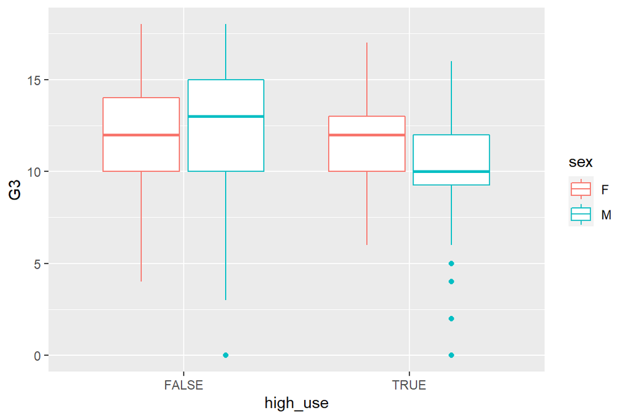

```r
# TASK 4, graphical summary

library(ggplot2)

# initialize a plot of high_use and G3, absences, failures and family relationship
g1 <- ggplot(alc_consu, aes(x = high_use, y = G3, col = sex))
g2 <- ggplot(alc_consu, aes(x = high_use, y = absences, col = sex))
g3 <- ggplot(alc_consu, aes(x = high_use, y = failures, col = sex))
g4 <- ggplot(alc_consu, aes(x = high_use, y = famrel, col = sex))

# define the plot as a boxplot and draw it
g1 + geom_boxplot() + ylab("G3")
```

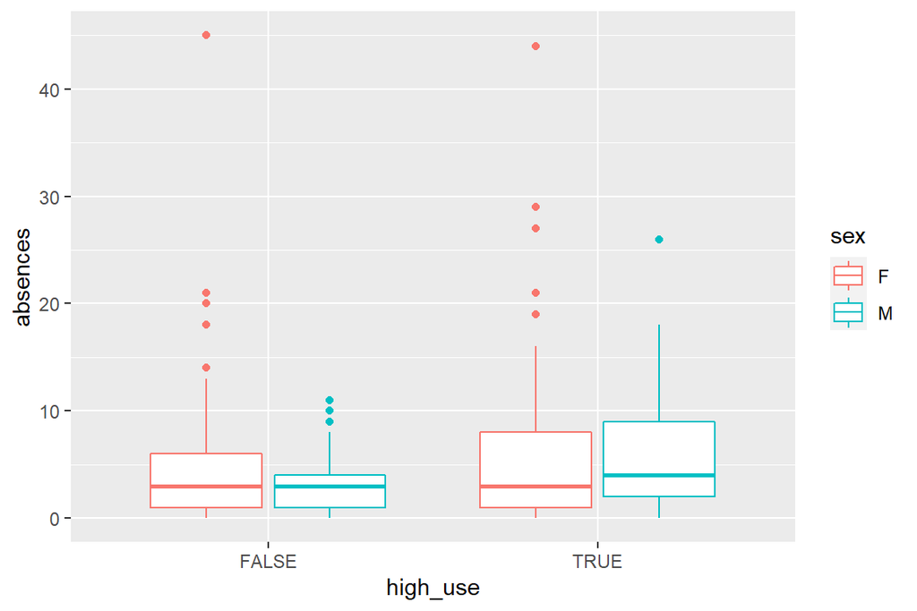

```r
g2 + geom_boxplot() + ylab("absences")
```

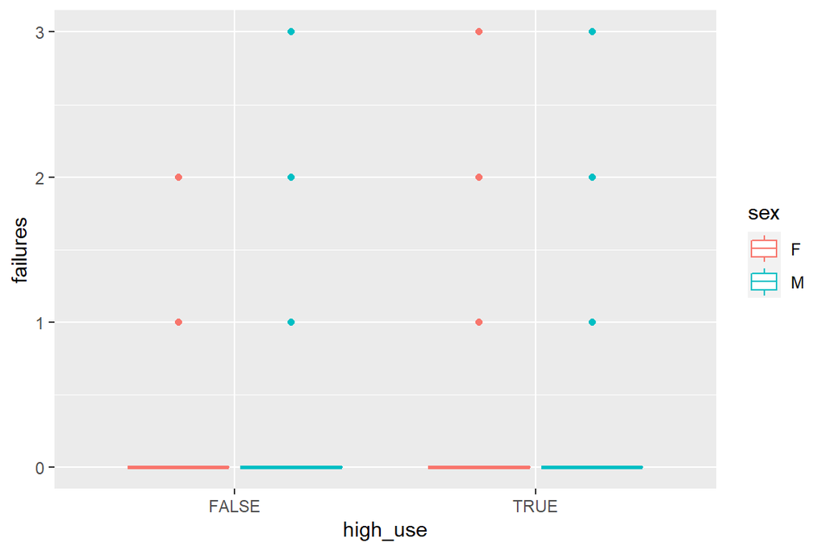

```r
g3 + geom_boxplot() + ylab("failures")
```

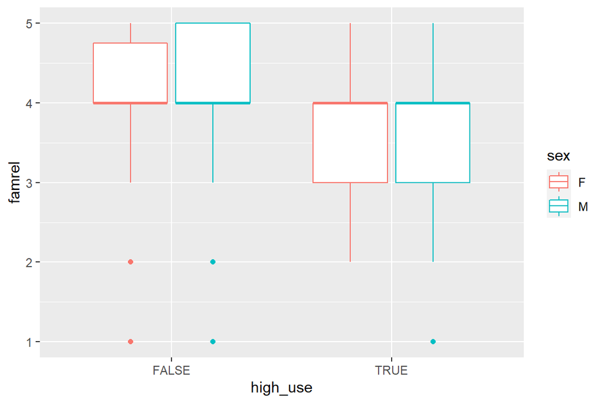

```r
g4 + geom_boxplot() + ylab("famrel")
```

**TASK 5, logistic regression**

Median **deviance residual** (-0.67) was small meaning that the model was not greatly biased.

There was no significant relationship between **grades** and alcohol consumption (p-value 0.31). High alcohol consumption had significant relationship between **failures** (p-value 0.01) and **absences** (p-value < 0.01). **Failures** and **absences** increased when alcohol consumption increased. P-value of quality of family relationship **(famrel)** was only a little over 0.05 so one could say it had also significant relationship to alcohol consumption. Quality of family relations got lower when alcohol consumption was higher.

**Null deviance:** The null deviance tells us how well we can predict our output only using the intercept. Smaller is better.

**Residual deviance:** The residual deviance tells us how well we can predict our output using the intercept and our inputs. Smaller is better

**The Akaike information criteria (AIC)** is used to estimate how well the model describes the patterns in data. It is used to compare models of the same dataset. Lower the score the better.

Explanations for null and residual deviance and the Akaike information criteria (AIC) were found from following [link](https://stats.stackexchange.com/questions/86351/interpretation-of-rs-output-for-binomial-regression).

```r
# TASK 5, logistics regression

# find the model with glm()
glmodel <- glm(high_use ~ G3 + failures + absences + famrel, data = alc_consu, family = "binomial")

# print out a summary of the model
summary(glmodel)
```

```
##
## Call:
## glm(formula = high_use ~ G3 + failures + absences + famrel, family = "binomial",
##     data = alc_consu)
##
## Deviance Residuals:
##     Min       1Q   Median       3Q      Max
## -2.1684  -0.7891  -0.6692   1.1496   1.9954
##
## Coefficients:
##             Estimate Std. Error z value Pr(>|z|)
## (Intercept)  0.06039    0.69094   0.087 0.930348
## G3          -0.03900    0.03860  -1.010 0.312332
## failures     0.54397    0.21204   2.565 0.010306 *
## absences     0.07941    0.02265   3.506 0.000456 ***
## famrel      -0.24827    0.12704  -1.954 0.050682 .
## ---
## Signif. codes:  0 '***' 0.001 '**' 0.01 '*' 0.05 '.' 0.1 ' ' 1
##
## (Dispersion parameter for binomial family taken to be 1)
##
##     Null deviance: 452.04  on 369  degrees of freedom
## Residual deviance: 419.07  on 365  degrees of freedom
## AIC: 429.07
##
## Number of Fisher Scoring iterations: 4
```

```r
# print out the coefficients of the model
coef(glmodel)
```

```
## (Intercept)          G3    failures    absences      famrel
##  0.06039255 -0.03900009  0.54396614  0.07941103 -0.24826624
```

**TASK 5, odds ratios**

Odds Ratio Interpretation [link](https://www.statisticshowto.com/odds-ratio)

- An odds ratio of exactly 1 means that exposure to property A does not affect the odds of property B.
- An odds ratio of more than 1 means that there is a higher odds of property B happening with exposure to property A.
- An odds ratio is less than 1 is associated with lower odds.

```r
# TASK 5, odds ratios

# compute odds ratios (OR)
OR <- coef(glmodel) %>% exp

# compute confidence intervals (CI)
CI <- confint(glmodel) %>% exp

# print out the odds ratios with their confidence intervals
cbind(OR, CI)
```

```
##                    OR     2.5 %   97.5 %
## (Intercept) 1.0622535 0.2716427 4.119475
## G3          0.9617506 0.8914779 1.037582
## failures    1.7228263 1.1429817 2.644153
## absences    1.0826492 1.0378918 1.134607
## famrel      0.7801522 0.6073480 1.001334
```

**TASK 6, predictions**

For this modelling I dropped variable G3 (grades) out of the model as it had no statistically significant relationship with high/low alcohol consumption.

Prediction was set to be true if the value of 'probability' was greater than 0.5.

242 individuals were correctly classified as low alcohol consumers (true negative) while 17 were classified wrongly as high alcohol consumers (false positive). 19 individuals were correctly classified as high alcohol consumers (true positive) while 92 individuals were classified wrongly as low alcohol consumers (false negative).

I tested the model by setting probability of high alcohol use to 0 and 1. With probability 0 average prediction error of the model was 0.3 and with probability of 1 average prediction error was 0.7. The model works better when there are no high alcohol consumers in the dataset.

```r
# TASK 6, predictions

glmodel_1 <- glm(high_use ~ failures + absences + famrel, data = alc_consu, family = "binomial")

# predict() the probability of high_use
probabilities <- predict(glmodel_1, type = "response")

# add the predicted probabilities to 'alc_consu'
alc_consu <- mutate(alc_consu, probability = probabilities)

# use the probabilities to make a prediction of high_use
alc_consu <- mutate(alc_consu, prediction = probability > 0.5)

# see the last ten original classes, predicted probabilities, and class predictions
select(alc_consu, failures, absences, famrel, high_use, probability, prediction) %>% tail(10)
```

```
##     failures absences famrel high_use probability prediction
##  1:        1        7      5     TRUE   0.3870516      FALSE
##  2:        0        3      4     TRUE   0.2393520      FALSE
##  3:        0        2      4     TRUE   0.2249096      FALSE
##  4:        0        4      3     TRUE   0.3047258      FALSE
##  5:        0        3      3    FALSE   0.2878313      FALSE
##  6:        0        4      4     TRUE   0.2544175      FALSE
##  7:        0        0      4    FALSE   0.1979156      FALSE
##  8:        1        4      4     TRUE   0.3887510      FALSE
##  9:        2        8      5     TRUE   0.5606861       TRUE
## 10:        1        0      4    FALSE   0.3150209      FALSE
```

```r
# tabulate the target variable versus the predictions
table(high_use = alc_consu$high_use, prediction = alc_consu$prediction)
```

```
##         prediction
## high_use FALSE TRUE
##    FALSE   242   17
##    TRUE     92   19
```

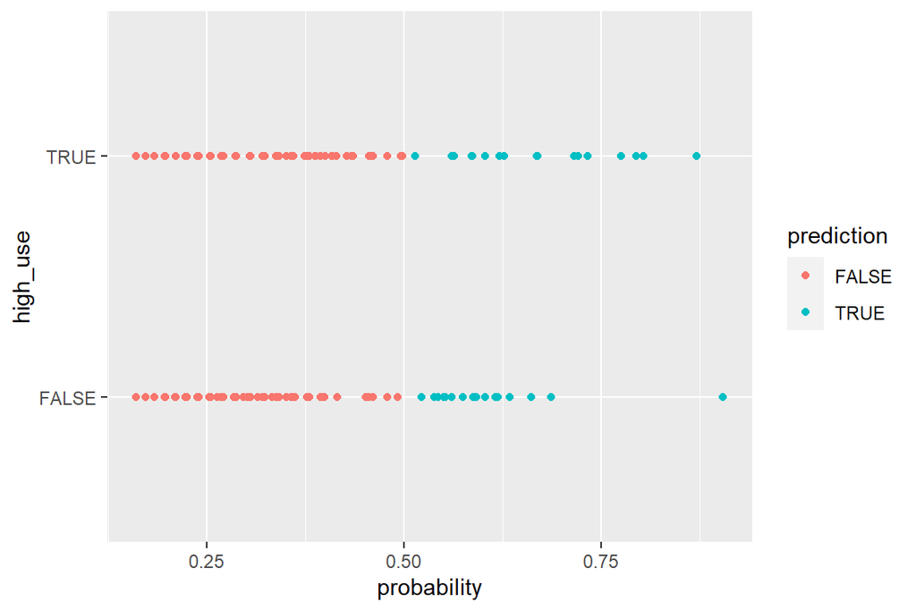

```r
# access dplyr and ggplot2
library(dplyr); library(ggplot2)

# initialize a plot of 'high_use' versus 'probability' in 'alc_consu'
g <- ggplot(alc_consu, aes(x = probability, y = high_use, col = prediction))

# define the geom as points and draw the plot
g + geom_point()
```

```r
# tabulate the target variable versus the predictions
table(high_use = alc_consu$high_use, prediction = alc_consu$prediction) %>% prop.table %>% addmargins
```

```
##         prediction
## high_use      FALSE       TRUE        Sum
##    FALSE 0.65405405 0.04594595 0.70000000
##    TRUE  0.24864865 0.05135135 0.30000000
##    Sum   0.90270270 0.09729730 1.00000000
```

```r
# define a loss function (average prediction error)
loss_func <- function(class, prob) {
  n_wrong <- abs(class - prob) > 0.5
  mean(n_wrong)
}

# call loss_func to compute the average number of wrong predictions in the (training) data
loss_func(class = alc_consu$high_use, prob = alc_consu$probability)
```

```
## [1] 0.2945946
```

```r
loss_func(class = alc_consu$high_use, prob = 0)
```

```
## [1] 0.3
```

```r
loss_func(class = alc_consu$high_use, prob = 1)
```

```
## [1] 0.7
```

**TASK 7, 10-fold cross-validation**

The 10-fold cross-validation of my model (high_use ~ failures + absences + famrel) resulted in prediction error of 0.3, which is little bit higher than datacamp model error 0.26.

```r
# compute the average number of wrong predictions in the (training) data


# K-fold cross-validation
library(boot)
cv <- cv.glm(data = alc_consu, cost = loss_func, glmfit = glmodel_1, K = 10)

# average number of wrong predictions in the cross validation
cv$delta[1]
```

```
## [1] 0.3108108
```

# 5 Exercise 4. Clustering and classification

*This week Linear Discriminant Analysis (LDA) and K-means clustering was used to study the Boston housing dataset.*

*LDA is commonly used as dimensionality reduction technique in the pre-processing step for pattern-classification and machine learning applications. Dataset is projected onto a lower-dimensional space with good class-separability in order avoid overfitting and also reduce computational costs.([Sebastian Raschka 2020](https://sebastianraschka.com/Articles/2014_python_lda.html#principal-component-analysis-vs-linear-discriminant-analysis))*

*Kmeans algorithm is an iterative algorithm that tries to partition the dataset into Kpre-defined distinct non-overlapping subgroups (clusters) where each data point belongs to only one group. It tries to make the intra-cluster data points as similar as possible while also keeping the clusters as different (far) as possible. ([Imad Dabbura 2018](https://towardsdatascience.com/k-means-clustering-algorithm-applications-evaluation-methods-and-drawbacks-aa03e644b48a)).*

**TASK 2, structure and dimensions of the data**

Boston dataset contains housing values of suburban areas in Boston. The dataframe has 506 observations of 14 variables. Variables are described in the following [link](https://stat.ethz.ch/R-manual/R-devel/library/MASS/html/Boston.html)

```r
date()
```

```
## [1] "Thu Dec 03 18:03:30 2020"
```

```r
# TASK 2

# access the MASS package
library(MASS)

# load the data
data("Boston")

# explore the dataset
str(Boston)
```

```
## 'data.frame':    506 obs. of  14 variables:
##  $ crim   : num  0.00632 0.02731 0.02729 0.03237 0.06905 ...
##  $ zn     : num  18 0 0 0 0 0 12.5 12.5 12.5 12.5 ...
##  $ indus  : num  2.31 7.07 7.07 2.18 2.18 2.18 7.87 7.87 7.87 7.87 ...
##  $ chas   : int  0 0 0 0 0 0 0 0 0 0 ...
##  $ nox    : num  0.538 0.469 0.469 0.458 0.458 0.458 0.524 0.524 0.524 0.524 ...
##  $ rm     : num  6.58 6.42 7.18 7 7.15 ...
##  $ age    : num  65.2 78.9 61.1 45.8 54.2 58.7 66.6 96.1 100 85.9 ...
##  $ dis    : num  4.09 4.97 4.97 6.06 6.06 ...
##  $ rad    : int  1 2 2 3 3 3 5 5 5 5 ...
##  $ tax    : num  296 242 242 222 222 222 311 311 311 311 ...
##  $ ptratio: num  15.3 17.8 17.8 18.7 18.7 18.7 15.2 15.2 15.2 15.2 ...
##  $ black  : num  397 397 393 395 397 ...
##  $ lstat  : num  4.98 9.14 4.03 2.94 5.33 ...
##  $ medv   : num  24 21.6 34.7 33.4 36.2 28.7 22.9 27.1 16.5 18.9 ...
```

**TASK 3, summary of the data and correlations**

In original Boston dataset variable means ranged from 0.07 (chas) to 408 (tax). The highest correlation was between variabless rad (index of accessibility of radial highways) and tax (full-value property-tax rate per $10,000). The higher the index of accessibility of radial highway gets the higher property tax rate got. There was also high correlation between concentration of nitrogen oxides and distance to employment center. The higher the distance the lower the concentrations.

```r
# TASK 3

library(corrplot)
library(tidyr)

#summary of the data
summary(Boston)
```

```
##       crim                zn             indus            chas
##  Min.   : 0.00632   Min.   :  0.00   Min.   : 0.46   Min.   :0.00000
##  1st Qu.: 0.08205   1st Qu.:  0.00   1st Qu.: 5.19   1st Qu.:0.00000
##  Median : 0.25651   Median :  0.00   Median : 9.69   Median :0.00000
##  Mean   : 3.61352   Mean   : 11.36   Mean   :11.14   Mean   :0.06917
##  3rd Qu.: 3.67708   3rd Qu.: 12.50   3rd Qu.:18.10   3rd Qu.:0.00000
##  Max.   :88.97620   Max.   :100.00   Max.   :27.74   Max.   :1.00000
##       nox               rm             age              dis
##  Min.   :0.3850   Min.   :3.561   Min.   :  2.90   Min.   : 1.130
##  1st Qu.:0.4490   1st Qu.:5.886   1st Qu.: 45.02   1st Qu.: 2.100
##  Median :0.5380   Median :6.208   Median : 77.50   Median : 3.207
##  Mean   :0.5547   Mean   :6.285   Mean   : 68.57   Mean   : 3.795
##  3rd Qu.:0.6240   3rd Qu.:6.623   3rd Qu.: 94.08   3rd Qu.: 5.188
##  Max.   :0.8710   Max.   :8.780   Max.   :100.00   Max.   :12.127
##       rad              tax           ptratio          black
##  Min.   : 1.000   Min.   :187.0   Min.   :12.60   Min.   :  0.32
##  1st Qu.: 4.000   1st Qu.:279.0   1st Qu.:17.40   1st Qu.:375.38
##  Median : 5.000   Median :330.0   Median :19.05   Median :391.44
##  Mean   : 9.549   Mean   :408.2   Mean   :18.46   Mean   :356.67
##  3rd Qu.:24.000   3rd Qu.:666.0   3rd Qu.:20.20   3rd Qu.:396.23
##  Max.   :24.000   Max.   :711.0   Max.   :22.00   Max.   :396.90
##      lstat            medv
##  Min.   : 1.73   Min.   : 5.00
##  1st Qu.: 6.95   1st Qu.:17.02
##  Median :11.36   Median :21.20
##  Mean   :12.65   Mean   :22.53
##  3rd Qu.:16.95   3rd Qu.:25.00
##  Max.   :37.97   Max.   :50.00
```

```r
# calculate the correlation matrix and round it
cor_matrix <- cor(Boston) %>% round(digits = 2)

# print the correlation matrix
cor_matrix
```

```
##          crim    zn indus  chas   nox    rm   age   dis   rad   tax ptratio
## crim     1.00 -0.20  0.41 -0.06  0.42 -0.22  0.35 -0.38  0.63  0.58    0.29
## zn      -0.20  1.00 -0.53 -0.04 -0.52  0.31 -0.57  0.66 -0.31 -0.31   -0.39
## indus    0.41 -0.53  1.00  0.06  0.76 -0.39  0.64 -0.71  0.60  0.72    0.38
## chas    -0.06 -0.04  0.06  1.00  0.09  0.09  0.09 -0.10 -0.01 -0.04   -0.12
## nox      0.42 -0.52  0.76  0.09  1.00 -0.30  0.73 -0.77  0.61  0.67    0.19
## rm      -0.22  0.31 -0.39  0.09 -0.30  1.00 -0.24  0.21 -0.21 -0.29   -0.36
## age      0.35 -0.57  0.64  0.09  0.73 -0.24  1.00 -0.75  0.46  0.51    0.26
## dis     -0.38  0.66 -0.71 -0.10 -0.77  0.21 -0.75  1.00 -0.49 -0.53   -0.23
## rad      0.63 -0.31  0.60 -0.01  0.61 -0.21  0.46 -0.49  1.00  0.91    0.46
## tax      0.58 -0.31  0.72 -0.04  0.67 -0.29  0.51 -0.53  0.91  1.00    0.46
## ptratio  0.29 -0.39  0.38 -0.12  0.19 -0.36  0.26 -0.23  0.46  0.46    1.00
## black   -0.39  0.18 -0.36  0.05 -0.38  0.13 -0.27  0.29 -0.44 -0.44   -0.18
## lstat    0.46 -0.41  0.60 -0.05  0.59 -0.61  0.60 -0.50  0.49  0.54    0.37
## medv    -0.39  0.36 -0.48  0.18 -0.43  0.70 -0.38  0.25 -0.38 -0.47   -0.51
##         black lstat  medv
## crim    -0.39  0.46 -0.39
## zn       0.18 -0.41  0.36
## indus   -0.36  0.60 -0.48
## chas     0.05 -0.05  0.18
## nox     -0.38  0.59 -0.43
## rm       0.13 -0.61  0.70
## age     -0.27  0.60 -0.38
## dis      0.29 -0.50  0.25
## rad     -0.44  0.49 -0.38
## tax     -0.44  0.54 -0.47
## ptratio -0.18  0.37 -0.51
## black    1.00 -0.37  0.33
## lstat   -0.37  1.00 -0.74
## medv     0.33 -0.74  1.00
```

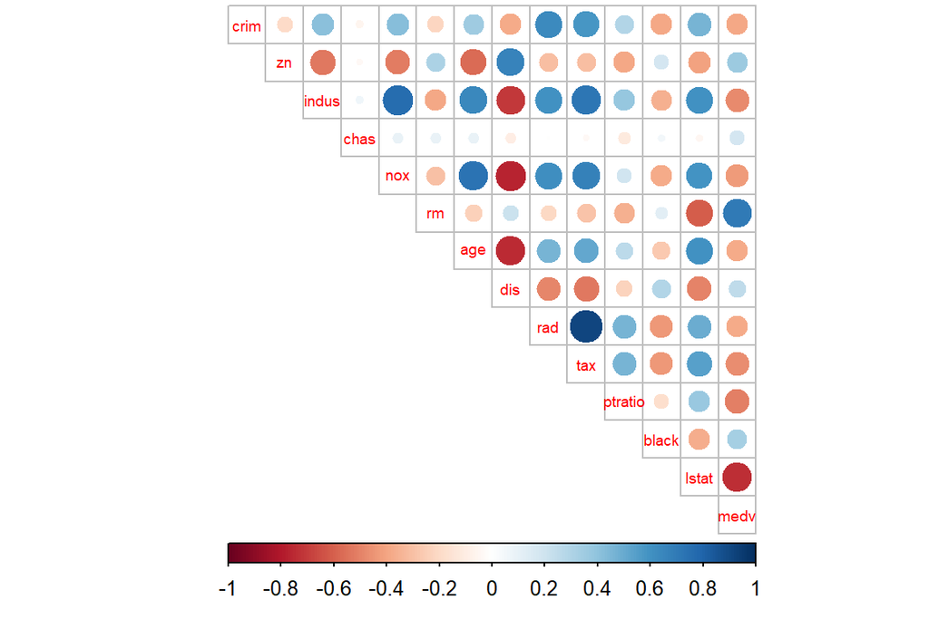

```r
# visualize the correlation matrix
corrplot(cor_matrix, method="circle", type="upper", cl.pos="b", tl.pos="d", tl.cex = 0.6)
```

```r
#https://www.statsandr.com/blog/correlogram-in-r-how-to-highlight-the-most-correlated-variables-in-a-dataset/
# devtools::install_github("laresbernardo/lares")
library(lares)

corr_cross(Boston, # name of dataset
  max_pvalue = 0.05, # display only significant correlations (at 5% level)
  top = 10 # display top 10 couples of variables (by correlation coefficient)
)
```

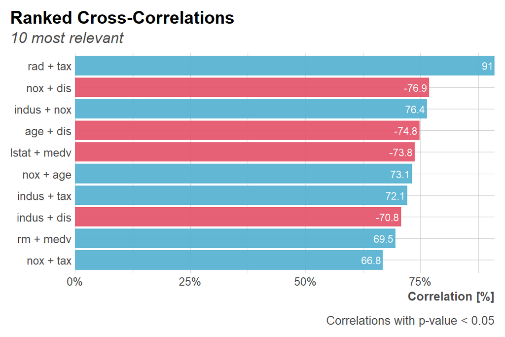

**TASK 4, scaling the data and creating test data sets**

After scaling the data all variable means were 0.

```r
# TASK 4

# center and standardize variables
boston_scaled <- scale(Boston)

# summaries of the scaled variables
summary(boston_scaled)
```

```
##       crim                 zn               indus              chas
##  Min.   :-0.419367   Min.   :-0.48724   Min.   :-1.5563   Min.   :-0.2723
##  1st Qu.:-0.410563   1st Qu.:-0.48724   1st Qu.:-0.8668   1st Qu.:-0.2723
##  Median :-0.390280   Median :-0.48724   Median :-0.2109   Median :-0.2723
##  Mean   : 0.000000   Mean   : 0.00000   Mean   : 0.0000   Mean   : 0.0000
##  3rd Qu.: 0.007389   3rd Qu.: 0.04872   3rd Qu.: 1.0150   3rd Qu.:-0.2723
##  Max.   : 9.924110   Max.   : 3.80047   Max.   : 2.4202   Max.   : 3.6648
##       nox                rm               age               dis
##  Min.   :-1.4644   Min.   :-3.8764   Min.   :-2.3331   Min.   :-1.2658
##  1st Qu.:-0.9121   1st Qu.:-0.5681   1st Qu.:-0.8366   1st Qu.:-0.8049
##  Median :-0.1441   Median :-0.1084   Median : 0.3171   Median :-0.2790
##  Mean   : 0.0000   Mean   : 0.0000   Mean   : 0.0000   Mean   : 0.0000
##  3rd Qu.: 0.5981   3rd Qu.: 0.4823   3rd Qu.: 0.9059   3rd Qu.: 0.6617
##  Max.   : 2.7296   Max.   : 3.5515   Max.   : 1.1164   Max.   : 3.9566
##       rad               tax             ptratio            black
##  Min.   :-0.9819   Min.   :-1.3127   Min.   :-2.7047   Min.   :-3.9033
##  1st Qu.:-0.6373   1st Qu.:-0.7668   1st Qu.:-0.4876   1st Qu.: 0.2049
##  Median :-0.5225   Median :-0.4642   Median : 0.2746   Median : 0.3808
##  Mean   : 0.0000   Mean   : 0.0000   Mean   : 0.0000   Mean   : 0.0000
##  3rd Qu.: 1.6596   3rd Qu.: 1.5294   3rd Qu.: 0.8058   3rd Qu.: 0.4332
##  Max.   : 1.6596   Max.   : 1.7964   Max.   : 1.6372   Max.   : 0.4406
##      lstat              medv
##  Min.   :-1.5296   Min.   :-1.9063
##  1st Qu.:-0.7986   1st Qu.:-0.5989
##  Median :-0.1811   Median :-0.1449
##  Mean   : 0.0000   Mean   : 0.0000
##  3rd Qu.: 0.6024   3rd Qu.: 0.2683
##  Max.   : 3.5453   Max.   : 2.9865
```

```r
# class of the boston_scaled object
class(boston_scaled)
```

```
## [1] "matrix" "array"
```

```r
# change the object to data frame
boston_scaled <- as.data.frame(boston_scaled)

# summary of the scaled crime rate
summary(boston_scaled$crim)
```

```
##      Min.   1st Qu.    Median      Mean   3rd Qu.      Max.
## -0.419367 -0.410563 -0.390280  0.000000  0.007389  9.924110
```

Categorical variable of the crime was created using scaled data and quantiles as break points. Original crime rate was replaced with the new categorical variable. Further dataset was divided to train and test sets.

```r
# create a quantile vector of crim and print it
bins <- quantile(boston_scaled$crim)
bins
```

```
##           0%          25%          50%          75%         100%
## -0.419366929 -0.410563278 -0.390280295  0.007389247  9.924109610
```

```r
# create a categorical variable 'crime'
crime <- cut(boston_scaled$crim, breaks = bins, include.lowest = TRUE, labels = c("low", "med_low", "med_high", "high"))

# look at the table of the new factor crime
table(crime)
```

```
## crime
##      low  med_low med_high     high
##      127      126      126      127
```

```r
# remove original crim from the dataset
boston_scaled <- dplyr::select(boston_scaled, -crim)

# add the new categorical value to scaled data
boston_scaled <- data.frame(boston_scaled, crime)

# number of rows in the Boston dataset
n <- nrow(boston_scaled)

# choose randomly 80% of the rows
ind <- sample(n,  size = n * 0.8)

# create train set
train <- boston_scaled[ind,]

# create test set
test <- boston_scaled[-ind,]

# save the correct classes from test data
correct_classes <- test$crime

# remove the crime variable from test data
test <- dplyr::select(test, -crime)
```

**TASK 5, linear discriminant analysis (LDA)**

LDA can be visualized with LDA biplot. LDA finds a combination of the variables that separate the target variable classes. High crime rate was clearly separated from other categories. Categories low, med_low and med_high were more or less overlapping each other.

```r
# TASK 5, linear discriminant analysis
lda.fit <- lda(crime ~ ., data = train)

# print the lda.fit object
lda.fit
```

```
## Call:
## lda(crime ~ ., data = train)
##
## Prior probabilities of groups:
##       low   med_low  med_high      high
## 0.2450495 0.2524752 0.2549505 0.2475248
##
## Group means:
##                  zn      indus         chas        nox         rm        age
## low       1.0065300 -0.9028912 -0.153023000 -0.9031651  0.4690572 -0.9430796
## med_low  -0.0704492 -0.2712680 -0.002135914 -0.5679583 -0.1229257 -0.3268826
## med_high -0.4031510  0.2070880  0.262810770  0.3936532  0.1022897  0.4174358
## high     -0.4872402  1.0171519 -0.114845058  1.0441609 -0.4917392  0.8042279
##                 dis        rad        tax     ptratio       black       lstat
## low       0.8993193 -0.6918543 -0.7316362 -0.51928349  0.36787900 -0.78178296
## med_low   0.3733929 -0.5528850 -0.4848638 -0.04648229  0.31758318 -0.12416791
## med_high -0.3915055 -0.3786473 -0.2835034 -0.24853183  0.05981629  0.05452466
## high     -0.8710666  1.6377820  1.5138081  0.78037363 -0.82830433  0.91586338
##                 medv
## low       0.54546394
## med_low  -0.01667857
## med_high  0.15013268
## high     -0.72716436
##
## Coefficients of linear discriminants:
##                 LD1         LD2         LD3
## zn       0.10575469  0.69935415 -0.83254521
## indus   -0.03252472 -0.15477392  0.37818744
## chas    -0.09060121 -0.11645066  0.09116032
## nox      0.37227276 -0.73003311 -1.35750275
## rm      -0.11404504 -0.05392940 -0.17450900
## age      0.32272946 -0.34251114  0.00753561
## dis     -0.12014935 -0.24357332  0.24654286
## rad      3.00530779  0.87483753  0.01680385
## tax     -0.01320434  0.06359589  0.35732368
## ptratio  0.11171956 -0.08232381 -0.16208599
## black   -0.13641657  0.01012971  0.11514111
## lstat    0.18822593 -0.17238222  0.23371397
## medv     0.13949728 -0.35280337 -0.31745047
##
## Proportion of trace:
##    LD1    LD2    LD3
## 0.9452 0.0417 0.0131
```

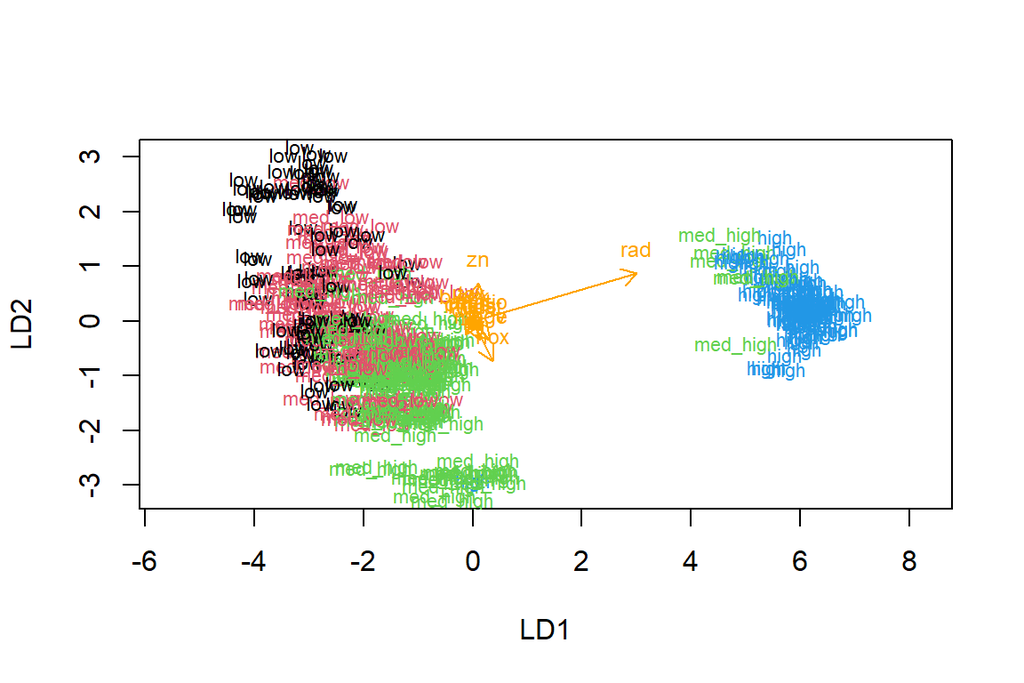

```r
# the function for lda biplot arrows
lda.arrows <- function(x, myscale = 1, arrow_heads = 0.1, color = "orange", tex = 0.75, choices = c(1,2)){
  heads <- coef(x)
  arrows(x0 = 0, y0 = 0,
         x1 = myscale * heads[,choices[1]],
         y1 = myscale * heads[,choices[2]], col=color, length = arrow_heads)
  text(myscale * heads[,choices], labels = row.names(heads),
       cex = tex, col=color, pos=3)
}

# target classes as numeric
classes <- as.numeric(train$crime)

# plot the lda results
plot(lda.fit, dimen = 2, col = classes, pch = classes)
lda.arrows(lda.fit, myscale = 1)
```

**TASK 6, LDA model predictions**

The crime rate classes were predicted with the LDA model and the results were cross tabulated.

```r
# predict classes with test data
lda.pred <- predict(lda.fit, newdata = test)

# cross tabulate the results
table(correct = correct_classes, predicted = lda.pred$class)
```

```
##           predicted
## correct    low med_low med_high high
##   low       14      14        0    0
##   med_low    2      18        4    0
##   med_high   1       7       15    0
##   high       0       0        0   27
```

```r
# tabulate the target variable versus the predictions
table(high_use = correct_classes, prediction = lda.pred$class) %>% prop.table %>% addmargins
```

```
##           prediction
## high_use           low     med_low    med_high        high         Sum
##   low      0.137254902 0.137254902 0.000000000 0.000000000 0.274509804
##   med_low  0.019607843 0.176470588 0.039215686 0.000000000 0.235294118
##   med_high 0.009803922 0.068627451 0.147058824 0.000000000 0.225490196
##   high     0.000000000 0.000000000 0.000000000 0.264705882 0.264705882
##   Sum      0.166666667 0.382352941 0.186274510 0.264705882 1.000000000
```

**TASK 7, distances between variables**

Distances between the scaled Boston dataset variables were calculated (Euclidean and Manhattan distance). Mean of the Euclidean distance was 4.9 and the Manhattan distance 13.5.

```r
library(MASS)

data('Boston')

# center and standardize variables
boston_scaled <- scale(Boston)

# change the object to data frame
boston_scaled <- as.data.frame(boston_scaled)

# euclidean distance matrix
dist_eu <- dist(boston_scaled)

# look at the summary of the distances
summary(dist_eu)
```

```
##    Min. 1st Qu.  Median    Mean 3rd Qu.    Max.
##  0.1343  3.4625  4.8241  4.9111  6.1863 14.3970
```

```r
# manhattan distance matrix
dist_man <- dist(boston_scaled, method = 'manhattan')

# look at the summary of the distances
summary(dist_man)
```

```
##    Min. 1st Qu.  Median    Mean 3rd Qu.    Max.
##  0.2662  8.4832 12.6090 13.5488 17.7568 48.8618
```

**K-means clustering**

With kmeans clustering we can calculate the distance matrix automatically.

One way to determine optimal number of clusters is to to look at how the total of within cluster sum of squares (WCSS) behaves when the number of cluster changes. According to datacamp the optimal number of clusters is when the total WCSS drops radically. The most radical drop stopped at cluster 2 where an elbow is formed so optimal number of clusters would be then 2. Drop still continues in the plot TWCSS and starts flatten out at cluster 6 onwards. So I decided to try two models with 2 and 6 clusters.

The K Means cluster plots (with colors) shows how well clusters differ from each other. More separate the better.

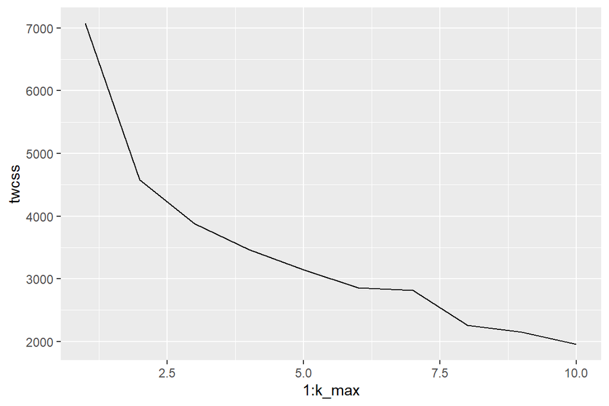

```r
set.seed(123) # to prevent K-means producing different results every time

# determine the number of clusters
k_max <- 10

# calculate the total within sum of squares
twcss <- sapply(1:k_max, function(k){kmeans(boston_scaled, k)$tot.withinss})

# visualize the results
library(ggplot2)
qplot(x = 1:k_max, y = twcss, geom = 'line')
```

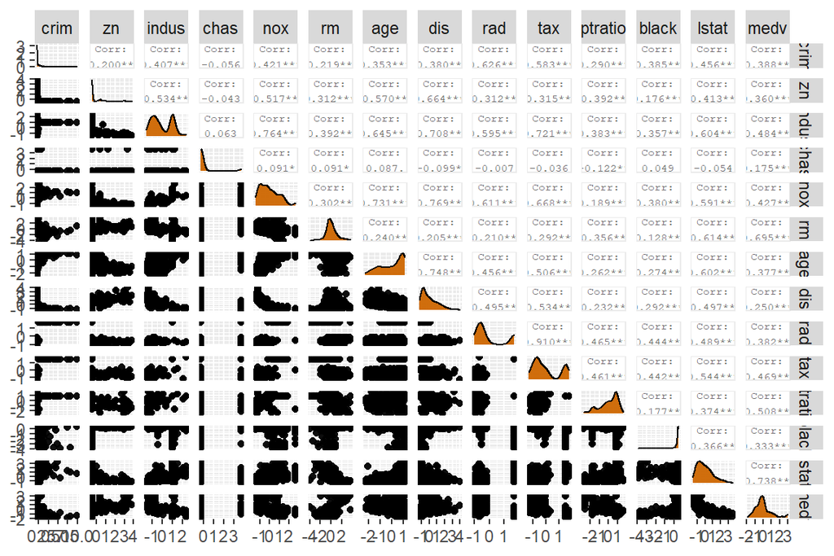

```r
# k-means clustering
km <-kmeans(boston_scaled, centers = 2)

# plot the scaled Boston dataset with clusters
library(GGally)
ggpairs(boston_scaled, upper = list(continuous = wrap("cor", size = 2)))
```

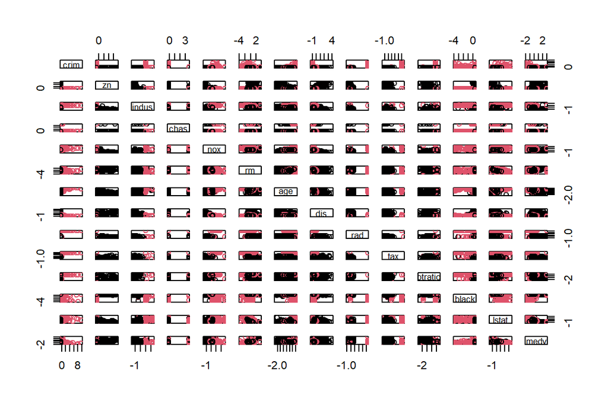

```r
pairs(boston_scaled, col = km$cluster)
```

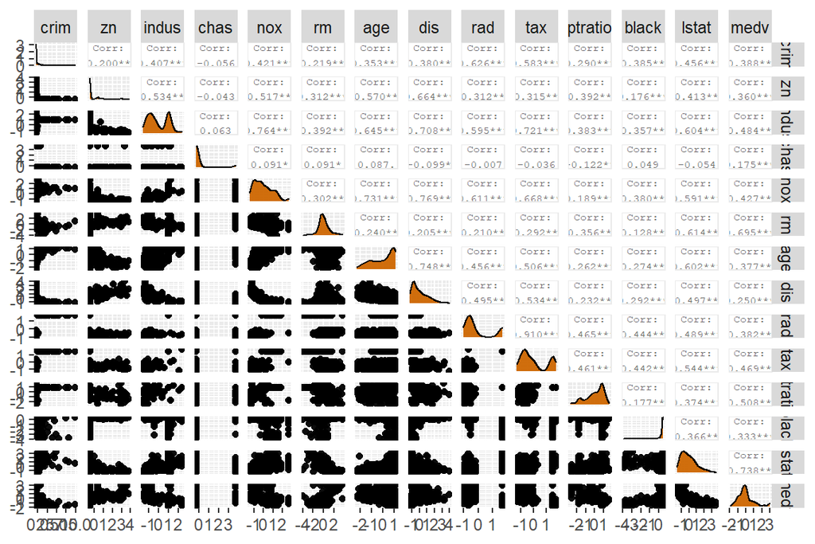

```r
# k-means clustering
km <-kmeans(boston_scaled, centers = 6)

# plot the scaled Boston dataset with clusters
library(GGally)
ggpairs(boston_scaled, upper = list(continuous = wrap("cor", size = 2)))
```

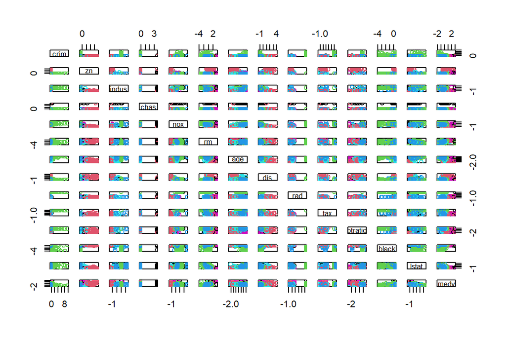

```r
pairs(boston_scaled, col = km$cluster)
```

# 6 Exercise 5. Dimensionality reduction techniques

*Dimension reduction methods are used to transform multidimensional data to 2- or 3-dimensional space. By reducing dimensionality it is easier to understand multidimensional phenomenas. Principal component analysis (PCA) is a simple, non-parametric method for extracting relevant information from data sets. With PCA it is possible to reduce complex data (continuous variables) set to a lower dimension to reveal the simplified structures that often underlie it. Principal component analysis is a standard tool in modern data-analysis. (Shlens 2014).*

*Multiple correspondence analysis (MCA) is used for discrete variables. In this method variables are transformed first to continuous scale followed by dimension reduction.*

**TASK 1**

The Highest negative correlation was between life expectancy and MMR (86%), meaning that the higher the life expectancy the lower MMR. The highest positive correlations was between life expectancy and expected mean years of education (79%).

```
## [1] "Thu Dec 03 18:04:47 2020"
```

```r
library(data.table)
human <- fread("F:/IODS_usb/IODS-project/data/human.csv")

# assigning country names as row values (again)
row.names(human) <- human$V1
human$V1 <- NULL

# dimensions of the data
dim(human)
```

```
## [1] 155   8
```

```r
# summary of the data
library(psych)
describe(human)
```

```
##          vars   n     mean       sd   median  trimmed      mad    min       max
## edu2_FM     1 155     0.85     0.24     0.94     0.87     0.12   0.17      1.50
## lab_FM      2 155     0.71     0.20     0.75     0.73     0.17   0.19      1.04
## edu_exp     3 155    13.18     2.84    13.50    13.24     2.97   5.40     20.20
## life_exp    4 155    71.65     8.33    74.20    72.40     7.56  49.00     83.50
## GNI         5 155 17627.90 18543.85 12040.00 14552.58 13337.47 581.00 123124.00
## MMR         6 155   149.08   211.79    49.00   104.70    63.75   1.00   1100.00
## ABR         7 155    47.16    41.11    33.60    41.62    35.73   0.60    204.80
## parRep      8 155    20.91    11.49    19.30    20.32    11.42   0.00     57.50
##              range  skew kurtosis      se
## edu2_FM       1.33 -0.76     0.55    0.02
## lab_FM        0.85 -0.87     0.05    0.02
## edu_exp      14.80 -0.20    -0.34    0.23
## life_exp     34.50 -0.76    -0.15    0.67
## GNI      122543.00  2.14     6.83 1489.48
## MMR        1099.00  2.03     4.16   17.01
## ABR         204.20  1.13     0.89    3.30
## parRep       57.50  0.55    -0.10    0.92
```

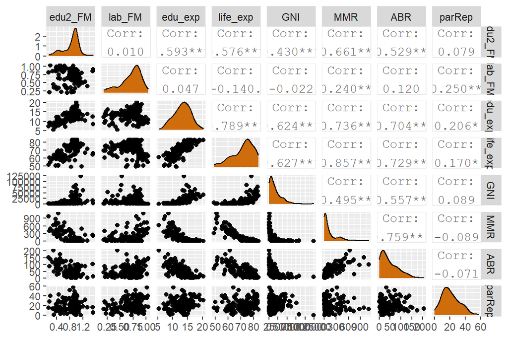

Figure 6.1: ggairs plot of the HDI data variables

```r
# Access GGally
library(GGally)

# visualize the 'human' variables
ggpairs(human)
```

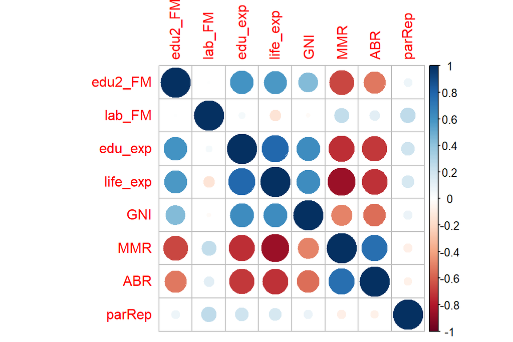

Figure 6.2: Correlation matrix of the HDI data variables

```r
# compute the correlation matrix and visualize it with corrplot
library(dplyr)
library(corrplot)
cor(human) %>% corrplot
```

```r
# devtools::install_github("laresbernardo/lares")
library(lares)

corr_cross(human, # name of dataset
  max_pvalue = 0.05, # display only significant correlations (at 5% level)
  top = 8 # display top 10 couples of variables (by correlation coefficient)
)
```

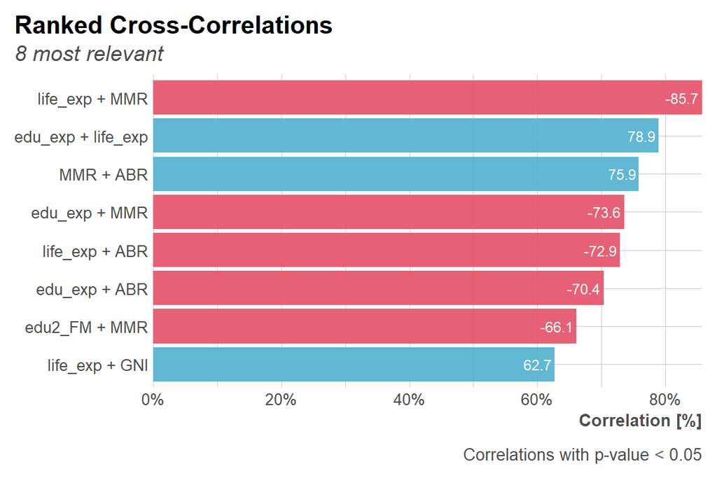

Figure 6.3: 8 most relevant cross-correlations of the HDI data variables

**TASK 2**

*PCA with non-scaled data*

First two principal components (PC) was chosen to analysis. The first PC captured 100% of the original variables variances. PCA computed with non-standardized variables results showed that GNI variable dominated the analysis, because it had clearly the highest variance compared to other variables. So it is not meaningful to compute PCA with non-scaled data. (note that although figure axis titles says standardized PC the analysis was done with non-scaled data)

```r
# packages
library(ggplot2)

# perform principal component analysis on non standardized (with the SVD method)
pca_human <- prcomp(human)
pca_human
```

```
## Standard deviations (1, .., p=8):
## [1] 1.854416e+04 1.855219e+02 2.518701e+01 1.145441e+01 3.766241e+00
## [6] 1.565912e+00 1.912052e-01 1.591112e-01
##
## Rotation (n x k) = (8 x 8):
##                    PC1           PC2           PC3           PC4           PC5
## edu2_FM   5.607472e-06 -0.0006713951 -3.412027e-05 -2.736326e-04  0.0022935252
## lab_FM   -2.331945e-07  0.0002819357  5.302884e-04 -4.692578e-03 -0.0022190154
## edu_exp   9.562910e-05 -0.0075529759  1.427664e-02 -3.313505e-02 -0.1431180282
## life_exp  2.815823e-04 -0.0283150248  1.294971e-02 -6.752684e-02 -0.9865644425
## GNI       9.999832e-01  0.0057723054 -5.156742e-04  4.932889e-05  0.0001135863
## MMR      -5.655734e-03  0.9916320120  1.260302e-01 -6.100534e-03 -0.0266373214
## ABR      -1.233961e-03  0.1255502723 -9.918113e-01  5.301595e-03 -0.0188618600
## parRep    5.526460e-05 -0.0032317269 -7.398331e-03 -9.971232e-01  0.0716401914
##                    PC6           PC7           PC8
## edu2_FM   2.180183e-02 -6.998623e-01  7.139410e-01
## lab_FM    3.264423e-02 -7.132267e-01 -7.001533e-01
## edu_exp   9.882477e-01  3.826887e-02  7.776451e-03
## life_exp -1.453515e-01 -5.380452e-03  2.281723e-03
## GNI      -2.711698e-05  8.075191e-07 -1.176762e-06
## MMR       1.695203e-03 -1.355518e-04  8.371934e-04
## ABR       1.273198e-02  8.641234e-05 -1.707885e-04
## parRep   -2.309896e-02  2.642548e-03  2.680113e-03
```

```r
summary(pca_human)
```

```
## Importance of components:
##                              PC1      PC2   PC3   PC4   PC5   PC6    PC7    PC8
## Standard deviation     1.854e+04 185.5219 25.19 11.45 3.766 1.566 0.1912 0.1591
## Proportion of Variance 9.999e-01   0.0001  0.00  0.00 0.000 0.000 0.0000 0.0000
## Cumulative Proportion  9.999e-01   1.0000  1.00  1.00 1.000 1.000 1.0000 1.0000
```

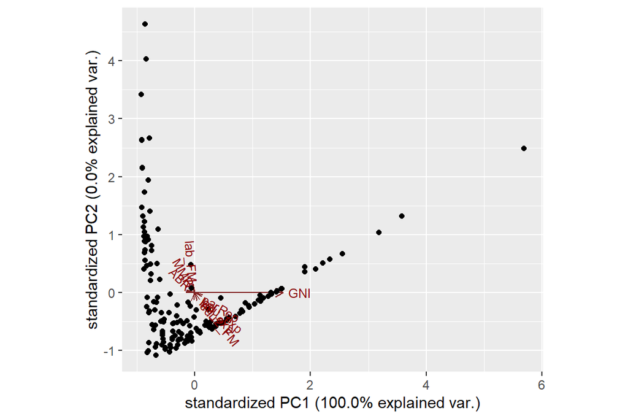

Figure 6.4: Principal component analysis with **non-standardized** data. The analysis is dominated by the GNI variable.

```r
# draw a biplot of the principal component representation and the original variables
library(ggbiplot)
ggbiplot(pca_human, choices = 1:2)
```

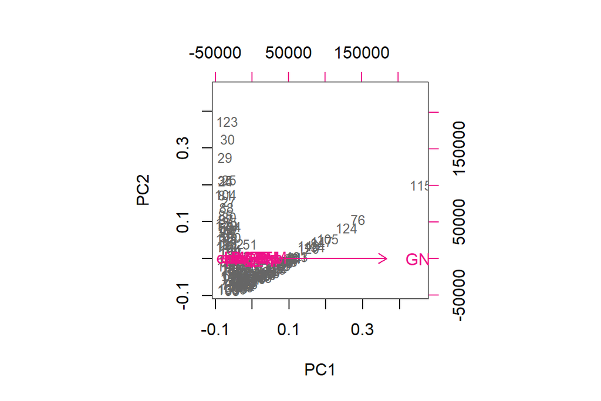

Figure 6.5: Principal component analysis with **non-standardized** data. The analysis is dominated by the GNI variable.

```r
biplot(pca_human, choices = 1:2, cex = c(0.8, 1), col = c("grey40", "deeppink2"))
```

**TASK 3 and 4**

*PCA with scaled variables and interpretations of the first two principal component dimensions*

After scaling the variables the means and standard deviations of each variable were 0 and 1, respectively, thus each of the variables were contributing now equally to analysis. The result biplot was now clearly different compared to non-scaled PCA. Now GNI variable was not dominating the PCA.

```r
# standardize the variables
human_std <- scale(human)

# print out summaries of the standardized variables
library(psych)
describe(human_std)
```

```
##          vars   n mean sd median trimmed  mad   min  max range  skew kurtosis
## edu2_FM     1 155    0  1   0.35    0.09 0.51 -2.82 2.66  5.48 -0.76     0.55
## lab_FM      2 155    0  1   0.23    0.10 0.84 -2.62 1.66  4.29 -0.87     0.05
## edu_exp     3 155    0  1   0.11    0.02 1.04 -2.74 2.47  5.21 -0.20    -0.34
## life_exp    4 155    0  1   0.31    0.09 0.91 -2.72 1.42  4.14 -0.76    -0.15
## GNI         5 155    0  1  -0.30   -0.17 0.72 -0.92 5.69  6.61  2.14     6.83
## MMR         6 155    0  1  -0.47   -0.21 0.30 -0.70 4.49  5.19  2.03     4.16
## ABR         7 155    0  1  -0.33   -0.13 0.87 -1.13 3.83  4.97  1.13     0.89
## parRep      8 155    0  1  -0.14   -0.05 0.99 -1.82 3.18  5.01  0.55    -0.10
##            se
## edu2_FM  0.08
## lab_FM   0.08
## edu_exp  0.08
## life_exp 0.08
## GNI      0.08
## MMR      0.08
## ABR      0.08
## parRep   0.08
```

```r
# perform principal component analysis (with the SVD method)
pca_human_std <- prcomp(human_std)
pca_human_std
```

```
## Standard deviations (1, .., p=8):
## [1] 2.0708380 1.1397204 0.8750485 0.7788630 0.6619563 0.5363061 0.4589994
## [8] 0.3222406
##
## Rotation (n x k) = (8 x 8):
##                  PC1         PC2         PC3         PC4        PC5         PC6
## edu2_FM   0.35664370 -0.03796058 -0.24223089  0.62678110 -0.5983585  0.17713316
## lab_FM   -0.05457785 -0.72432726 -0.58428770  0.06199424  0.2625067 -0.03500707
## edu_exp   0.42766720 -0.13940571 -0.07340270 -0.07020294  0.1659678 -0.38606919
## life_exp  0.44372240  0.02530473  0.10991305 -0.05834819  0.1628935 -0.42242796
## GNI       0.35048295 -0.05060876 -0.20168779 -0.72727675 -0.4950306  0.11120305
## MMR      -0.43697098 -0.14508727 -0.12522539 -0.25170614 -0.1800657  0.17370039
## ABR      -0.41126010 -0.07708468  0.01968243  0.04986763 -0.4672068 -0.76056557
## parRep    0.08438558 -0.65136866  0.72506309  0.01396293 -0.1523699  0.13749772
##                  PC7         PC8
## edu2_FM   0.05773644  0.16459453
## lab_FM   -0.22729927 -0.07304568
## edu_exp   0.77962966 -0.05415984
## life_exp -0.43406432  0.62737008
## GNI      -0.13711838 -0.16961173
## MMR       0.35380306  0.72193946
## ABR      -0.06897064 -0.14335186
## parRep    0.00568387 -0.02306476
```

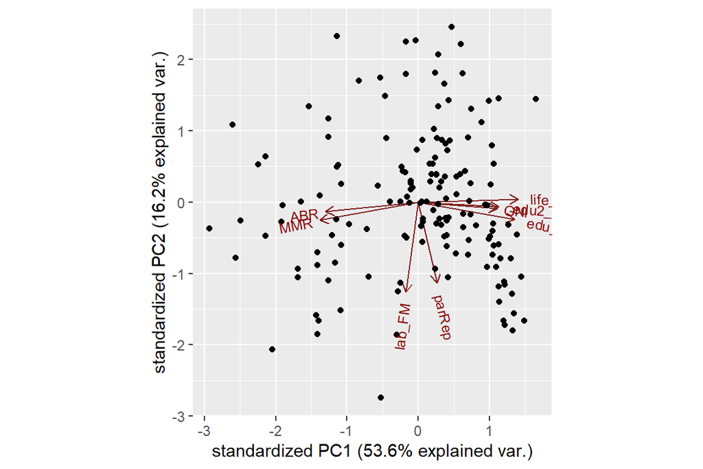

```r
# draw a biplot of the principal component representation and the standardized variables
library(ggbiplot)
ggbiplot(pca_human_std, choices = 1:2)
```

**TASK5**

*Loading tea dataset*

The tea dataset had 300 observations of 6 variables describing what kind of tea, with whom, where and with sugar or no people like to drink their tea.

```r
library(FactoMineR)
library(ggplot2)
library(tidyr)

# read in tea data
data("tea")

# column names to keep in the dataset
keep_columns <- c("Tea", "How", "how", "sugar", "where", "lunch")

# select the 'keep_columns' to create a new dataset
tea_time <- tea[keep_columns]

# look at the summaries and structure of the data
summary(tea_time)
```

```
##         Tea         How                      how           sugar
##  black    : 74   alone:195   tea bag           :170   No.sugar:155
##  Earl Grey:193   lemon: 33   tea bag+unpackaged: 94   sugar   :145
##  green    : 33   milk : 63   unpackaged        : 36
##                  other:  9
##                   where           lunch
##  chain store         :192   lunch    : 44
##  chain store+tea shop: 78   Not.lunch:256
##  tea shop            : 30
##
```

```r
str(tea_time)
```

```
## 'data.frame':    300 obs. of  6 variables:
##  $ Tea  : Factor w/ 3 levels "black","Earl Grey",..: 1 1 2 2 2 2 2 1 2 1 ...
##  $ How  : Factor w/ 4 levels "alone","lemon",..: 1 3 1 1 1 1 1 3 3 1 ...
##  $ how  : Factor w/ 3 levels "tea bag","tea bag+unpackaged",..: 1 1 1 1 1 1 1 1 2 2 ...
##  $ sugar: Factor w/ 2 levels "No.sugar","sugar": 2 1 1 2 1 1 1 1 1 1 ...
##  $ where: Factor w/ 3 levels "chain store",..: 1 1 1 1 1 1 1 1 2 2 ...
##  $ lunch: Factor w/ 2 levels "lunch","Not.lunch": 2 2 2 2 2 2 2 2 2 2 ...
```

*Visualising tea dataset*

Most of the people prefer to buy their Earl grey tea bags from chain stores, drink tea without lemon, milk or other substances and not after/ no lunch. It was about 50/50 divided to sugar users and not using sugar.

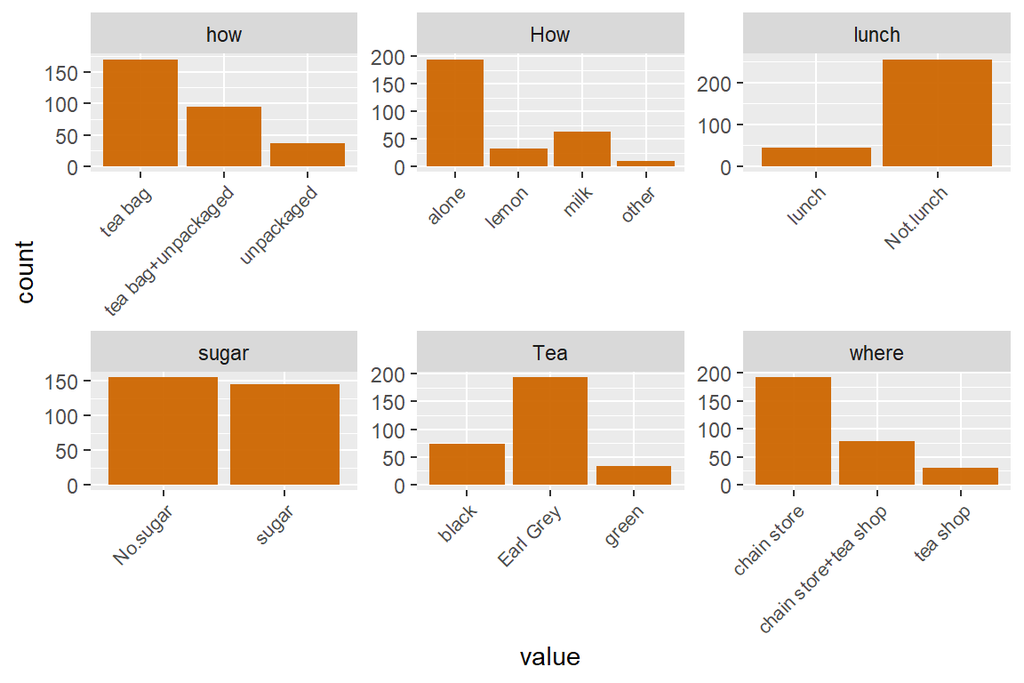

Figure 6.7: Distributions of the tea dataset variables

```r
# visualize the dataset
gather(tea_time) %>% ggplot(aes(value)) + facet_wrap("key", scales = "free") + geom_bar() + theme(axis.text.x = element_text(angle = 45, hjust = 1, size = 8))
```

*Multiple Correspondence Analysis*

```r
# multiple correspondence analysis
mca <- MCA(tea_time, graph = FALSE)

# summary of the model
summary(mca)
```

```
##
## Call:
## MCA(X = tea_time, graph = FALSE)
##
##
## Eigenvalues
##                        Dim.1   Dim.2   Dim.3   Dim.4   Dim.5   Dim.6   Dim.7
## Variance               0.279   0.261   0.219   0.189   0.177   0.156   0.144
## % of var.             15.238  14.232  11.964  10.333   9.667   8.519   7.841
## Cumulative % of var.  15.238  29.471  41.435  51.768  61.434  69.953  77.794
##                        Dim.8   Dim.9  Dim.10  Dim.11
## Variance               0.141   0.117   0.087   0.062
## % of var.              7.705   6.392   4.724   3.385
## Cumulative % of var.  85.500  91.891  96.615 100.000
##
## Individuals (the 10 first)
##                       Dim.1    ctr   cos2    Dim.2    ctr   cos2    Dim.3
## 1                  | -0.298  0.106  0.086 | -0.328  0.137  0.105 | -0.327
## 2                  | -0.237  0.067  0.036 | -0.136  0.024  0.012 | -0.695
## 3                  | -0.369  0.162  0.231 | -0.300  0.115  0.153 | -0.202
## 4                  | -0.530  0.335  0.460 | -0.318  0.129  0.166 |  0.211
## 5                  | -0.369  0.162  0.231 | -0.300  0.115  0.153 | -0.202
## 6                  | -0.369  0.162  0.231 | -0.300  0.115  0.153 | -0.202
## 7                  | -0.369  0.162  0.231 | -0.300  0.115  0.153 | -0.202
## 8                  | -0.237  0.067  0.036 | -0.136  0.024  0.012 | -0.695
## 9                  |  0.143  0.024  0.012 |  0.871  0.969  0.435 | -0.067
## 10                 |  0.476  0.271  0.140 |  0.687  0.604  0.291 | -0.650
##                       ctr   cos2
## 1                   0.163  0.104 |
## 2                   0.735  0.314 |
## 3                   0.062  0.069 |
## 4                   0.068  0.073 |
## 5                   0.062  0.069 |
## 6                   0.062  0.069 |
## 7                   0.062  0.069 |
## 8                   0.735  0.314 |
## 9                   0.007  0.003 |
## 10                  0.643  0.261 |
##
## Categories (the 10 first)
```

[output cut: 16 more lines]

```
## lemon                3.226 |   1.329  14.771   0.218   8.081 |
## milk                 2.422 |   0.013   0.003   0.000   0.116 |
## other                5.534 |  -2.524  14.526   0.197  -7.676 |
## tea bag             -6.941 |  -0.065   0.183   0.006  -1.287 |
## tea bag+unpackaged  11.956 |   0.019   0.009   0.000   0.226 |
## unpackaged          -6.482 |   0.257   0.602   0.009   1.640 |
##
## Categorical variables (eta2)
##                      Dim.1 Dim.2 Dim.3
## Tea                | 0.126 0.108 0.410 |
## How                | 0.076 0.190 0.394 |
## how                | 0.708 0.522 0.010 |
## sugar              | 0.065 0.001 0.336 |
## where              | 0.702 0.681 0.055 |
## lunch              | 0.000 0.064 0.111 |
```

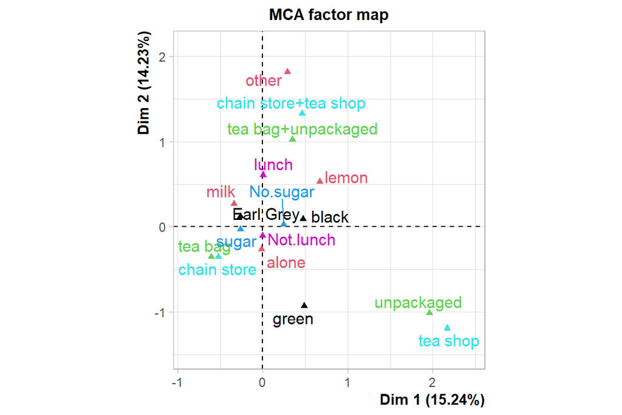

Figure 6.8: Multiple correspondence analysis plot of tea data

```r
# visualize MCA with FactoMineR biplot
plot.MCA(mca, invisible=c("ind"), habillage = "quali")
```

# 7 Exercise 6. Analysis of longitudinal data

**Exploring the data**

In the BPRS dataset 40 male subjects were randomly assigned to one of two treatment groups and each subject was rated on the brief psychiatric rating scale (BPRS) measured before treatment began (week 0) and then at weekly intervals for eight weeks. The BPRS assesses the level of 18 symptom constructs such as hostility, suspiciousness, hallucinations and grandiosity; each of these is rated from one (not present) to seven (extremely severe). The scale is used to evaluate patients suspected of having schizophrenia (Vehkalahti & Everitt 2019).

RATS dataset includes data from a nutrition study conducted in three groups of rats (Crowder and Hand, 1990). The three groups were put on different diets, and each animal’s body weight (grams) was recorded repeatedly over a 9-week period.

```
## [1] "Thu Dec 03 18:04:58 2020"
```

```r
library(data.table)

BPRSL <- fread("F:/IODS_usb/IODS-project/data/BPRSL.csv")
RATSL <- fread("F:/IODS_usb/IODS-project/data/RATSL.csv")
BPRS <- fread("F:/IODS_usb/IODS-project/data/BPRS.csv")
RATS <- fread("F:/IODS_usb/IODS-project/data/RATS.csv")

str(BPRSL)
```

```
## Classes 'data.table' and 'data.frame':   360 obs. of  5 variables:
##  $ treatment: int  1 1 1 1 1 1 1 1 1 1 ...
##  $ subject  : int  1 2 3 4 5 6 7 8 9 10 ...
##  $ weeks    : chr  "week0" "week0" "week0" "week0" ...
##  $ bprs     : int  42 58 54 55 72 48 71 30 41 57 ...
##  $ week     : int  0 0 0 0 0 0 0 0 0 0 ...
##  - attr(*, ".internal.selfref")=<externalptr>
```

```r
str(RATSL)
```

```
## Classes 'data.table' and 'data.frame':   176 obs. of  5 variables:
##  $ ID    : int  1 2 3 4 5 6 7 8 9 10 ...
##  $ Group : int  1 1 1 1 1 1 1 1 2 2 ...
##  $ WD    : chr  "WD1" "WD1" "WD1" "WD1" ...
##  $ Weight: int  240 225 245 260 255 260 275 245 410 405 ...
##  $ Time  : int  1 1 1 1 1 1 1 1 1 1 ...
##  - attr(*, ".internal.selfref")=<externalptr>
```

```r
str(BPRS)
```

```
## Classes 'data.table' and 'data.frame':   40 obs. of  11 variables:
##  $ treatment: int  1 1 1 1 1 1 1 1 1 1 ...
##  $ subject  : int  1 2 3 4 5 6 7 8 9 10 ...
##  $ week0    : int  42 58 54 55 72 48 71 30 41 57 ...
##  $ week1    : int  36 68 55 77 75 43 61 36 43 51 ...
##  $ week2    : int  36 61 41 49 72 41 47 38 39 51 ...
##  $ week3    : int  43 55 38 54 65 38 30 38 35 55 ...
##  $ week4    : int  41 43 43 56 50 36 27 31 28 53 ...
##  $ week5    : int  40 34 28 50 39 29 40 26 22 43 ...
##  $ week6    : int  38 28 29 47 32 33 30 26 20 43 ...
##  $ week7    : int  47 28 25 42 38 27 31 25 23 39 ...
##  $ week8    : int  51 28 24 46 32 25 31 24 21 32 ...
##  - attr(*, ".internal.selfref")=<externalptr>
```

```r
str(RATS)
```

```
## Classes 'data.table' and 'data.frame':   16 obs. of  13 variables:
##  $ ID   : int  1 2 3 4 5 6 7 8 9 10 ...
##  $ Group: int  1 1 1 1 1 1 1 1 2 2 ...
##  $ WD1  : int  240 225 245 260 255 260 275 245 410 405 ...
##  $ WD8  : int  250 230 250 255 260 265 275 255 415 420 ...
##  $ WD15 : int  255 230 250 255 255 270 260 260 425 430 ...
##  $ WD22 : int  260 232 255 265 270 275 270 268 428 440 ...
##  $ WD29 : int  262 240 262 265 270 275 273 270 438 448 ...
##  $ WD36 : int  258 240 265 268 273 277 274 265 443 460 ...
##  $ WD43 : int  266 243 267 270 274 278 276 265 442 458 ...
##  $ WD44 : int  266 244 267 272 273 278 271 267 446 464 ...
##  $ WD50 : int  265 238 264 274 276 284 282 273 456 475 ...
##  $ WD57 : int  272 247 268 273 278 279 281 274 468 484 ...
##  $ WD64 : int  278 245 269 275 280 281 284 278 478 496 ...
##  - attr(*, ".internal.selfref")=<externalptr>
```

```r
# converting categorical variables of both dataset into factors
BPRSL$treatment <- factor(BPRSL$treatment)
BPRSL$subject <- factor(BPRSL$subject)
RATSL$ID <- factor(RATSL$ID)
RATSL$Group <- factor(RATSL$Group)
```

**Plotting the non-standardized weights of the diet groups of the rats**

On the RATS data diet group 1 had clearly lower weights in comparison to diet groups 2 and 3. In all groups it seemed that weights had increasing trend during the diet periods. In diet group 2 there was one individual with clearly higher weight than the others and diet groups 1 and 3 one individual each that had lower weight than the others.

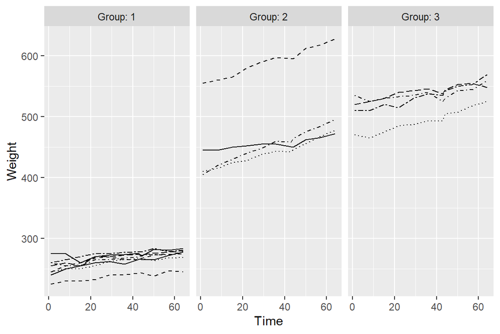

Figure 7.1: Weights by diet group for the RATS data

```r
#Access the package ggplot2
library(ggplot2)
library(tidyr)
library(dplyr)

# Draw the plot
ggplot(RATSL, aes(x = Time, y = Weight, linetype = ID)) +
  geom_line() +
  scale_linetype_manual(values = rep(1:10, times=4)) +
  facet_grid(. ~ Group, labeller = label_both) +
  theme(legend.position = "none") +
  scale_y_continuous(limits = c(min(RATSL$Weight), max(RATSL$Weight)))
```

**Plotting the standardized weights of rat diet groups**

```r
# Standardise the variable Weight
RATSL <- RATSL %>%
  group_by(Time) %>%
  mutate(stdweight = (Weight - mean(Weight))/sd(Weight) ) %>%
  ungroup()

# Glimpse the data
glimpse(RATSL)
```

```
## Rows: 176
## Columns: 6
## $ ID        <fct> 1, 2, 3, 4, 5, 6, 7, 8, 9, 10, 11, 12, 13, 14, 15, 16, 1,...
## $ Group     <fct> 1, 1, 1, 1, 1, 1, 1, 1, 2, 2, 2, 2, 3, 3, 3, 3, 1, 1, 1, ...
## $ WD        <chr> "WD1", "WD1", "WD1", "WD1", "WD1", "WD1", "WD1", "WD1", "...
## $ Weight    <int> 240, 225, 245, 260, 255, 260, 275, 245, 410, 405, 445, 55...
## $ Time      <int> 1, 1, 1, 1, 1, 1, 1, 1, 1, 1, 1, 1, 1, 1, 1, 1, 8, 8, 8, ...
## $ stdweight <dbl> -1.1362255, -1.2541867, -1.0969051, -0.9789439, -1.018264...
```

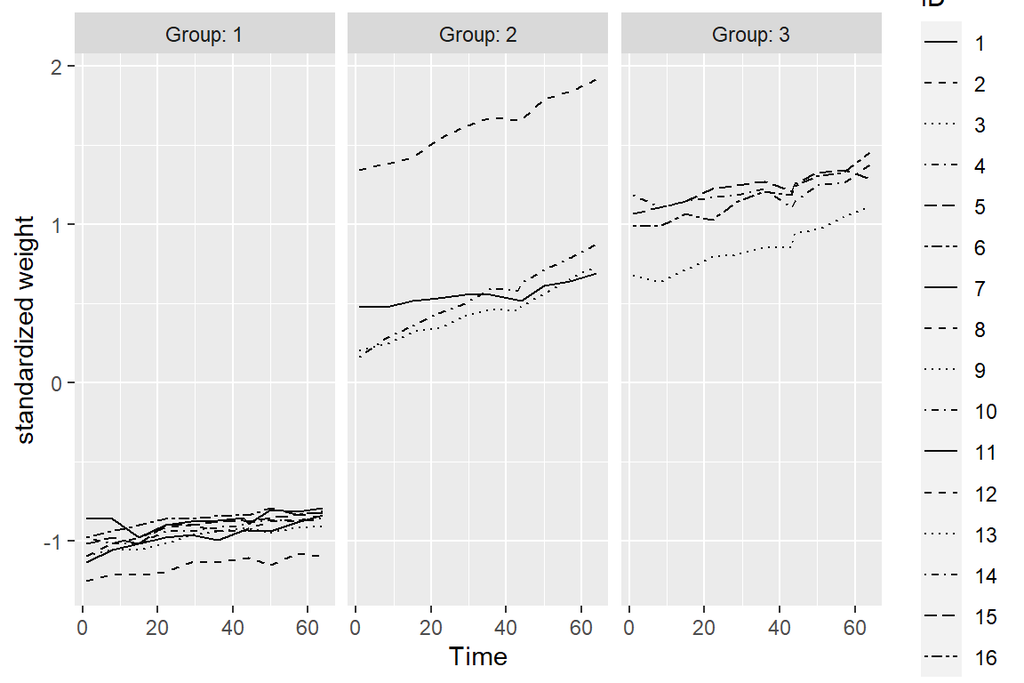

Figure 7.2: Standardized weights of rat diet groups

```r
# Plot again with the standardised weight
ggplot(RATSL, aes(x = Time, y = stdweight, linetype = ID)) +
  geom_line() +
  scale_linetype_manual(values = rep(1:10, times=4)) +
  facet_grid(. ~ Group, labeller = label_both) +
  scale_y_continuous(name = "standardized weight")
```

**Plotting the mean profiles of diet groups**

```r
# Number of time points, baseline (week 1) included
n <- RATSL$Time %>% unique() %>% length()

# Summary data with mean and standard error of weight by diet group and time
RATSS <- RATSL %>%
  group_by(Group,Time) %>%
  summarise(mean = mean(Weight), se = sd(Weight)/sqrt(n) ) %>%
  ungroup()

# Glimpse the data
glimpse(RATSS)
```

```
## Rows: 1
## Columns: 2
## $ mean <dbl> 384.483
## $ se   <dbl> 38.34032
```

```r
# Plot the mean profiles
ggplot(RATSS, aes(x = Time, y = mean, linetype = Group, shape = Group)) +
  geom_line() +
  scale_linetype_manual(values = c(1,2,3)) +
  geom_point(size=3) +
  scale_shape_manual(values = c(1,2,3)) +
  geom_errorbar(aes(ymin = mean - se, ymax = mean + se, linetype="1"), width=0.3) +
  theme(legend.position = c(0.9,0.5)) +
  scale_y_continuous(name = "mean(weight) +/- se(weight)")
```

[output not shown]

**Finding outliers**

```r
# Create a summary data by Group and ID with mean as the summary variable (ignoring WD 1).
RATSL8S <- RATSL %>%
  filter(Time > 1) %>%
  group_by(Group, ID) %>%
  summarise( mean=mean(Weight) ) %>%
  ungroup()

# Glimpse the data
glimpse(RATSL8S)
```

```
## Rows: 1
## Columns: 1
## $ mean <dbl> 386.3375
```

```r
# Draw a boxplot of the mean versus diet group
ggplot(RATSL8S, aes(x = Group, y = mean)) +
  geom_boxplot() +
  stat_summary(fun.y = "mean", geom = "point", shape=23, size=4, fill = "white") +
  scale_y_continuous(name = "mean(weight), WD 8-64")
```

[output not shown]

**Removing outliers**

```r
# Create a new data by filtering the outlier and adjust the ggplot code the draw the plot again with the new data
RATSL8S1 <- RATSL8S %>% filter(ID != 2 & ID != 12 & ID != 13)
```

[output not shown]

```r
# Draw a boxplot of the mean versus diet group
ggplot(RATSL8S1, aes(x = Group, y = mean)) +
  geom_boxplot() +
  stat_summary(fun.y = "mean", geom = "point", shape=23, size=4, fill = "white") +
  scale_y_continuous(name = "mean(weight), WD 8-64")
```

[output not shown]

**Analysis of variance (ANOVA)**

```r
# Add the baseline from the original data as a new variable to the summary data
RATSL8S2 <- RATSL8S %>%
  mutate(baseline = RATS$WD1)
```

[output not shown]

```r
# Fit the linear model with the mean as the response
fit <- lm(mean ~ baseline + Group, data = RATSL8S2)
```

[output not shown]

```r
# Compute the analysis of variance table for the fitted model with anova()
anova(fit)
```

[output not shown]

```r
# computing anova between diet groups
fit2 <- aov(mean~Group, data = RATSL8S2)
```

[output not shown]

```r
TukeyHSD(fit2)
```

[output not shown]

**Plotting BPRSL data**

It looks like there was significant (p-value < 0.01) reduction in bprs values during the 9 week period but there was no significant difference between treatment group 1 and 2 (p-value > 0.05)

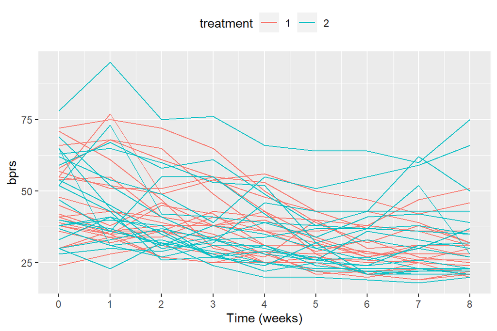

Figure 7.5: Bprs values over 9 week period

```r
# dim(BPRSL)

# create new variable to distinguish subjects of treatment groups

BPRSL$sID <- as.factor(paste(BPRSL$treatment, BPRSL$subject, sep = ""))

# plot the BPRSL data
ggplot(BPRSL, aes(x = week, y = bprs, group = sID)) +
  geom_line(aes(color = treatment)) +
  scale_x_continuous(name = "Time (weeks)", breaks = seq(0, 8, 1)) +
  scale_y_continuous(name = "bprs") +
  theme(legend.position = "top")
```

```r
# create a regression model BPRS_reg
BPRS_reg <- lm(bprs ~ week + treatment, data = BPRSL)

# print out a summary of the model
summary(BPRS_reg)
```

```
##
## Call:
## lm(formula = bprs ~ week + treatment, data = BPRSL)
##
## Residuals:
##     Min      1Q  Median      3Q     Max
## -22.454  -8.965  -3.196   7.002  50.244
##
## Coefficients:
##             Estimate Std. Error t value Pr(>|t|)
## (Intercept)  46.4539     1.3670  33.982   <2e-16 ***
## week         -2.2704     0.2524  -8.995   <2e-16 ***
## treatment2    0.5722     1.3034   0.439    0.661
## ---
## Signif. codes:  0 '***' 0.001 '**' 0.01 '*' 0.05 '.' 0.1 ' ' 1
##
## Residual standard error: 12.37 on 357 degrees of freedom
## Multiple R-squared:  0.1851, Adjusted R-squared:  0.1806
## F-statistic: 40.55 on 2 and 357 DF,  p-value: < 2.2e-16
```

**Random intercept model**

In the random intercept model, the linear regression fit intercept of each subject can vary from other subjects.  
There were no big difference in intercept and slope estimates in comparison to linear model, but standard errors of intercept and treatment 2 were higher and the week variable's lower in random intercept model.

```r
# access library lme4
library(lme4)

# Create a random intercept model
BPRS_ref <- lmer(bprs ~ week + treatment + (1 | sID), data = BPRSL, REML = FALSE)

# Print the summary of the model
summary(BPRS_ref)
```

```
## Linear mixed model fit by maximum likelihood  ['lmerMod']
## Formula: bprs ~ week + treatment + (1 | sID)
##    Data: BPRSL
##
##      AIC      BIC   logLik deviance df.resid
##   2582.9   2602.3  -1286.5   2572.9      355
##
## Scaled residuals:
##      Min       1Q   Median       3Q      Max
## -2.27506 -0.59909 -0.06104  0.44226  3.15835
##
## Random effects:
##  Groups   Name        Variance Std.Dev.
##  sID      (Intercept) 97.39    9.869
##  Residual             54.23    7.364
## Number of obs: 360, groups:  sID, 40
##
## Fixed effects:
##             Estimate Std. Error t value
## (Intercept)  46.4539     2.3521  19.750
## week         -2.2704     0.1503 -15.104
## treatment2    0.5722     3.2159   0.178
##
## Correlation of Fixed Effects:
##            (Intr) week
## week       -0.256
## treatment2 -0.684  0.000
```

**Random intercept and random slope model**

In a random intercept and random slope model the linear regression fits for each subject can vary in intercept but also in slope from other subjects. This way it is possible to account for the individual differences in the subjects' bprs profiles, but also study the effect of time.

Treatment 2 slope estimate (1.51) was now much higher in comparison to previous linear and random intercept model (both 0.57). Random intercept and slope model was significantly different (p-value < 0.01) when compared to random intercept model.

```r
# create a random intercept and random slope model
BPRS_ref1 <- lmer(bprs ~ week + treatment + (week | sID), data = BPRSL, REML = FALSE)

# print a summary of the model
summary(BPRS_ref1)
```

```
## Linear mixed model fit by maximum likelihood  ['lmerMod']
## Formula: bprs ~ week + treatment + (week | sID)
##    Data: BPRSL
##
##      AIC      BIC   logLik deviance df.resid
##   2523.2   2550.4  -1254.6   2509.2      353
##
## Scaled residuals:
##     Min      1Q  Median      3Q     Max
## -2.4655 -0.5150 -0.0920  0.4347  3.7353
##
## Random effects:
##  Groups   Name        Variance Std.Dev. Corr
##  sID      (Intercept) 167.827  12.955
##           week          2.331   1.527   -0.67
##  Residual              36.747   6.062
## Number of obs: 360, groups:  sID, 40
##
## Fixed effects:
##             Estimate Std. Error t value
## (Intercept)  45.9830     2.6470  17.372
## week         -2.2704     0.2713  -8.370
## treatment2    1.5139     3.1392   0.482
##
## Correlation of Fixed Effects:
##            (Intr) week
## week       -0.545
## treatment2 -0.593  0.000
```

```r
# perform an ANOVA test on the two models
anova(BPRS_ref1, BPRS_ref)
```

```
## Data: BPRSL
## Models:
## BPRS_ref: bprs ~ week + treatment + (1 | sID)
## BPRS_ref1: bprs ~ week + treatment + (week | sID)
##           npar    AIC    BIC  logLik deviance  Chisq Df Pr(>Chisq)
## BPRS_ref     5 2582.9 2602.3 -1286.5   2572.9
## BPRS_ref1    7 2523.2 2550.4 -1254.6   2509.2 63.663  2  1.499e-14 ***
## ---
## Signif. codes:  0 '***' 0.001 '**' 0.01 '*' 0.05 '.' 0.1 ' ' 1
```

**Random intercept and random slope model with interaction**

In our final model we fit a random intercept and slope model that allows for a group × time interaction. In this model slope estimate of treatment 2 is now negative (-2.3) and standard reached the highest value (4.2) in comparison to previous models.

Interaction model is not significantly (p-value > 0.05) different from BPRS_ref1 model. In conclusion treatment does lead improved bprs values over time, but does not have interaction with time.

```r
# create a random intercept and random slope model
BPRS_ref2 <- lmer(bprs ~ week * treatment + (week | sID), data = BPRSL, REML = FALSE)

# print a summary of the model
summary(BPRS_ref2)
```

```
## Linear mixed model fit by maximum likelihood  ['lmerMod']
## Formula: bprs ~ week * treatment + (week | sID)
##    Data: BPRSL
##
##      AIC      BIC   logLik deviance df.resid
##   2523.5   2554.5  -1253.7   2507.5      352
##
## Scaled residuals:
##     Min      1Q  Median      3Q     Max
## -2.4747 -0.5256 -0.0866  0.4435  3.7884
##
## Random effects:
##  Groups   Name        Variance Std.Dev. Corr
##  sID      (Intercept) 164.204  12.814
##           week          2.203   1.484   -0.66
##  Residual              36.748   6.062
## Number of obs: 360, groups:  sID, 40
##
## Fixed effects:
##                 Estimate Std. Error t value
## (Intercept)      47.8856     2.9840  16.047
## week             -2.6283     0.3752  -7.006
## treatment2       -2.2911     4.2200  -0.543
## week:treatment2   0.7158     0.5306   1.349
##
## Correlation of Fixed Effects:
##             (Intr) week   trtmn2
## week        -0.668
## treatment2  -0.707  0.473
## wek:trtmnt2  0.473 -0.707 -0.668
```

```r
# perform an ANOVA test on the four models
anova(BPRS_ref2, BPRS_ref1)
```

```
## Data: BPRSL
## Models:
## BPRS_ref1: bprs ~ week + treatment + (week | sID)
## BPRS_ref2: bprs ~ week * treatment + (week | sID)
##           npar    AIC    BIC  logLik deviance Chisq Df Pr(>Chisq)
## BPRS_ref1    7 2523.2 2550.4 -1254.6   2509.2
## BPRS_ref2    8 2523.5 2554.6 -1253.7   2507.5  1.78  1     0.1821
```

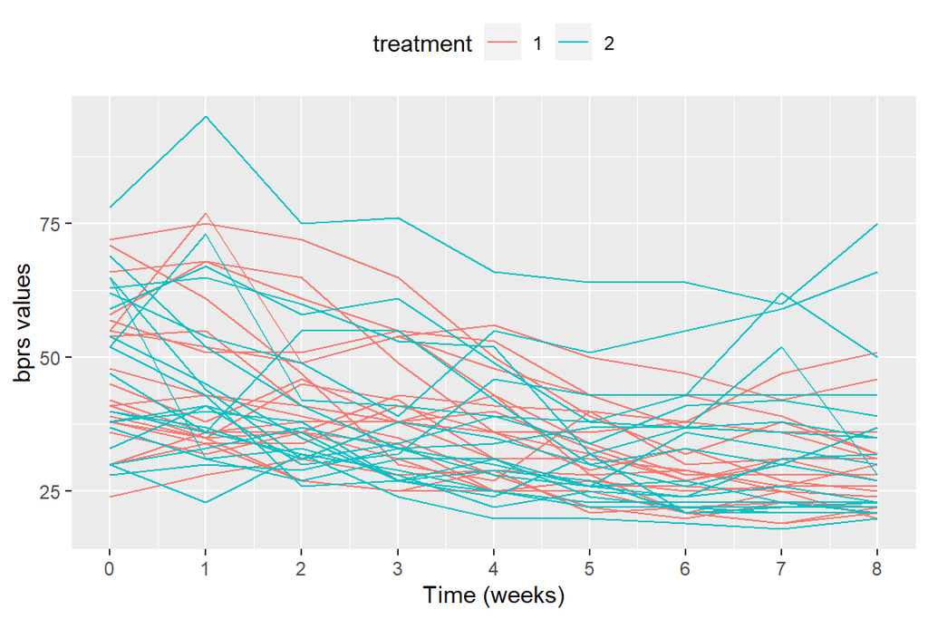

```r
# draw the plot of BPRSL
ggplot(BPRSL, aes(x = week, y = bprs, group = sID)) +
  geom_line(aes(color = treatment)) +
  scale_x_continuous(name = "Time (weeks)", breaks = seq(0, 8, 1)) +
  scale_y_continuous(name = "bprs values") +
  theme(legend.position = "top")
```

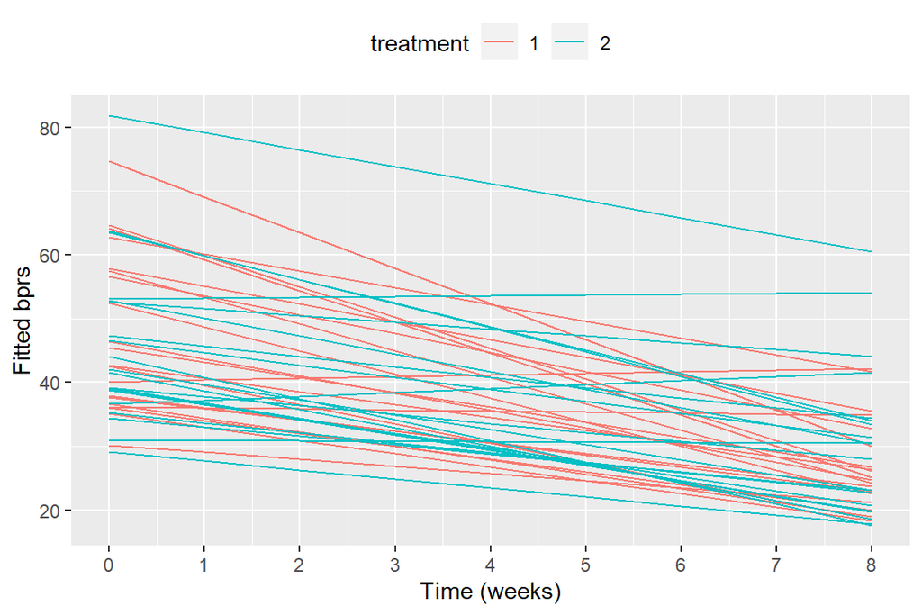

Figure 7.7: Fitted bprs values over 9 week period

```r
# Create a vector of the fitted values
Fitted <- fitted(BPRS_ref2)

# Create a new column fitted to BPRSL
BPRSL <- BPRSL %>%
  mutate(Fitted)

# draw the plot of the fitted BPRSL
ggplot(BPRSL, aes(x = week, y = Fitted, group = sID)) +
  geom_line(aes(color = treatment)) +
  scale_x_continuous(name = "Time (weeks)", breaks = seq(0, 8, 1)) +
  scale_y_continuous(name = "Fitted bprs") +
  theme(legend.position = "top")
```